# Python_for_Introductory_Statistics_V2

## 7.3 Box Plot

[Watch demo video](https://youtu.be/lXy8U6cvdw4)

Box plots (also called box-and-whisker plots or box-whisker plots) give a good graphical image of the concentration of the data. A box plot is constructed from five values: the minimum value, the first quartile, the median, the third quartile, and the maximum value.

Syntax

```
import matplotlib.pyplot as plt
plt.boxplot(x)
```

```
81, 21, 53, 32, 80, 13, 26, 42, 35, 41, 14, 25, 87, 62, 46,
                  40, 32, 52, 85, 28, 17, 36, 83, 79, 18, 50, 17, 36, 36,
                  19
```

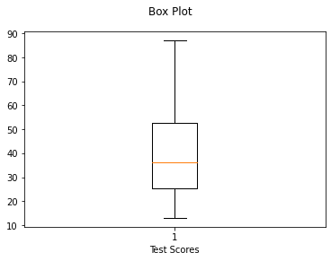

```python
import matplotlib.pyplot as plt


x = [81, 21, 53, 32, 80, 13, 26, 42, 35, 41, 14, 25, 87, 62, 46, 40,
             32, 52, 85, 28, 17, 36, 83, 79, 18, 50, 17, 36, 36, 19]

plt.boxplot(x)

plt.suptitle("Box Plot")
plt.xlabel("Test Scores")
```

```
81, 21, 53, 32, 80, 13, 26, 42, 35, 41, 14, 25, 87, 62, 46,
                  40, 32, 52, 85, 28, 17, 36, 83, 79, 18, 50, 17, 36, 36,
                  19
```

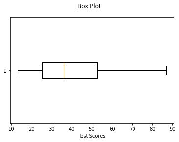

```python
import matplotlib.pyplot as plt


x = [81, 21, 53, 32, 80, 13, 26, 42, 35, 41, 14, 25, 87, 62, 46, 40,
             32, 52, 85, 28, 17, 36, 83, 79, 18, 50, 17, 36, 36, 19]


plt.boxplot(x,vert=False)  # add vert=False
plt.suptitle("Box Plot")
plt.xlabel("Test Scores")
```

Example: Below is the list of ages of US Senators (2020). Write a program to draw a box plot.

```
81,81,80,80,80,80,78,78,78,77,77,75,75,74,74,74,73,72,72,71,71,71,71,70
                  ,70,
                  70,70,68,68,68,68,68,67,67,67,66,66,65,65,65,65,64,64,64,64,64,64,63,63,
                  63,63,62,62,62,62,62,61,61,61,60,60,59,59,59,59,59,59,59,59,58,58,57,57,
                  56,56,55,54,54,54,54,54,53,53,52,52,52,52,52,51,50,49,48,46,45,44,43,43,
                  43,42,41
```

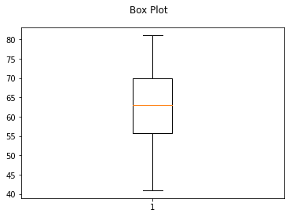

```python
import matplotlib.pyplot as plt


x = [81,81,80,80,80,80,78,78,78,77,77,75,75,74,74,74,73,72,72,71,71,71,71,70,70,
        70,70,68,68,68,68,68,67,67,67,66,66,65,65,65,65,64,64,64,64,64,64,63,63,
        63,63,62,62,62,62,62,61,61,61,60,60,59,59,59,59,59,59,59,59,58,58,57,57,
        56,56,55,54,54,54,54,54,53,53,52,52,52,52,52,51,50,49,48,46,45,44,43,43,
        43,42,41]

plt.boxplot(x)

plt.suptitle("Box Plot")
```

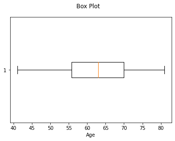

```python
import matplotlib.pyplot as plt


x = [81,81,80,80,80,80,78,78,78,77,77,75,75,74,74,74,73,72,72,71,71,71,71,70,70,
        70,70,68,68,68,68,68,67,67,67,66,66,65,65,65,65,64,64,64,64,64,64,63,63,
        63,63,62,62,62,62,62,61,61,61,60,60,59,59,59,59,59,59,59,59,58,58,57,57,
        56,56,55,54,54,54,54,54,53,53,52,52,52,52,52,51,50,49,48,46,45,44,43,43,
        43,42,41]

plt.boxplot(x,vert=False)

plt.suptitle("Box Plot")

plt.xlabel("Age")
```

### Outliers

Example: For the data below, construct a **horizontal** box plot to identify any outliers.

`1, 2, 2, 3, 3, 3, 3, 4, 7, 9,25`

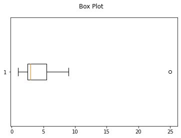

```python
import matplotlib.pyplot as plt

x=[1, 2, 2, 3, 3, 3, 3, 4, 7, 9,25]

plt.boxplot(x,vert=False)
plt.suptitle("Box Plot")
```

25 is identified as an outlier in the boxplot above marked with `o`. Any value below the left whisker or above the right whisker is considered an outlier.

# 8. Discrete Probability Distributions

A numerical variable whose value depends on the outcome of a chance or random event is called a **random variable**. If the set of possible values of a random variable is countable or finite, it is called a **discrete random variable**.

A discrete probability distribution function has two characteristics:

- Each probability is between zero and one, inclusive.
- The sum of the probabilities is one.

## 8.1 Expected Values and Standard Deviations

[Watch demo video](https://youtu.be/Kkil-XJJDkE)

If the probability distribution of the random variable $X$ is given by $p(x)$, then:

1. The expected value of a random variable X is given by $E(X)=\mu = \Sigma xp(x)$
2. The standard deviation of the random variable X is given by $\sigma = \sqrt{E(X-\mu)^2} = \sqrt{\Sigma (x-\mu)^2p(x)}$

Syntax for expected value

```
import numpy as np
np.average(x, weights=prob)
```

Syntax for population standard deviation

```
import numpy as np
np.sqrt(np.cov(x, aweights=prob, ddof=0))
```

Example: The number of electronic devices per household in a neighborhood and their corresponding probabilities are given on the table below. Find the expected value and standard deviation of the number of devices per household in this neighborhood.

| x | p(x) |
| --- | --- |
| 0 | .01 |
| 1 | .02 |
| 2 | .13 |
| 3 | .33 |
| 4 | .51 |

```python
import numpy as np

x = [0,1,2,3,4]
prob = [.01,.02,.13,.33,.51]

expected_value = np.average(x,weights=prob)
expected_value
```

```
3.31
```

Interpretation: The mean number of electronic devices per household is 3.31.

```python
import numpy as np

x = [0,1,2,3,4]
prob = [.01,.02,.13,.33,.51]

standard_deviation = np.sqrt(np.cov(x, aweights=prob, ddof=0))
standard_deviation
```

```
0.8449260322655469
```

Interpretation: The mean number of electronic devices per household is 3.31 with a standard deviation of 0.845.

## 8.2 Binomial Probability

If an experiment consists of $n$ identical and independent trials, with probability of success $p$ (remains the same for each trial), then the random variable $X$ defined as the number of successes in $n$ trials is a binomial random variable and the probability of $x$ successes is given by:

$P(X=x)=\binom{n}{x}p^k(1-p)^{n-x}$

where $x=0,1,2,3,...,n$

The syntax for $P(X=x)$, given n and p is

```
from scipy import stats
stats.binom.pmf(x,n,p)
```

The syntax for cumulative probability $P(X\le)$, given n and p is

```
from scipy import stats
stats.binom.cdf(x,n,p)
```

The syntax for mean and standard deviation is given by:

```
from scipy import stats
stats.binom.mean(n,p)
stats.binom.std(n,p)
```

Example: Find $P(X=10)$ if $p=0.6,n=12$

$P(x=10)=\binom{12}{10}6^{10}(1-0.6)^{12-10}$

Here x=10, n=12 and p=0.6.

```python
from scipy import stats
stats.binom.pmf(10, 12, 0.6)
```

```
0.06385228185599987
```

Example: For a Binomial distribution with 12 number of trials and probability of success 0.6, find the cumulative probabilities $P(x\le 2)=\Sigma_1^.6\binom{12}{2}.6^2(1-.6)^{12-2}$. Here x=2, p=0.6 and n=12.

```python
from scipy import stats
stats.binom.cdf(k=2, n=12, p=0.6)  # same as stats.binom.cdf(2, 12, 0.6)
```

```
0.00281018368
```

Interpretation: $P(X \le 2)=0.00281018368$

Example: A manufacturing machine has a 5% defect rate. Write a `scipy.stats` program to compute the following:

- If 6 items are chosen at random, what is the probability of exactly 2 defects.

```python
from scipy import stats

stats.binom.pmf(2,6,0.05)
```

```
0.030543984375000013
```

Interpretation: The probability of exactly two out of six defects is 0.030543984375000013

Example: A manufacturing machine has a 5% defect rate. Write a `scipy.stats` program to compute the following:

- If 6 items are chosen at random, what is the probability that 3 or less will have a defect?

```python
from scipy import stats
stats.binom.cdf(3,6,0.05)
```

```
0.99991359375
```

Interpretation: The probability of 3 or less defects is 0.99991359375

Example: A manufacturing machine has a 5% defect rate. Write a `scipy.stats` program to compute the following:

- If 6 items are chosen at random, what is the probability that at least two defects?

```python
from scipy import stats
1-stats.binom.cdf(1,6,0.05)
```

```
0.03277382812500007
```

Interpretation: The probability of at least two defects is 0.03277382812500007

Example: 20% of cars fail emission inspections in IL. If 15 cars are randomly selected, what is the probability that exactly three fail.

Here x=3, p=.2 and n=15

[Watch demo video](https://youtu.be/cGxKpZ7HiNE)

```python
from scipy import stats
stats.binom.pmf(3,15,.2)
```

```
0.2501388953190411
```

Example: 20% of cars fail emission inspections in IL. If 15 cars are randomly selected, what is the probability that at most five fail?

[Watch demo video](https://youtu.be/bdylm6A16NU)

```python
from scipy import stats
stats.binom.cdf(5,15,.2)
```

```
0.938948570382336
```

Interpretation: $P(X \le 5)=0.938948570382336$

Example: 20% of cars fail emission inspections in IL. If 15 cars are randomly selected, what is the probability that at least five fail?

$P(X \ge 5) = 1 - P(X \le 4)$

```python
from scipy import stats
1 - stats.binom.cdf(4,15,.2)
```

```
0.16423372393676794
```

Interpretation: $P(X \ge 5)=0.16423372393676794$

Example: 20% of cars fail emission inspections in IL.15 cars are randomly selected from IL. Make a probability distribution table for each outcome.

```python
from scipy import stats
import numpy as np
x = np.arange(0,15+1)  #generates [0,1,2,..,15]
y = stats.binom.pmf(x,15,.2)

prob = zip(x,y)
list(prob)
```

```
[(0, 0.035184372088831996),
 (1, 0.13194139533312002),
 (2, 0.23089744183296135),
 (3, 0.2501388953190411),
 (4, 0.18760417148928044),
 (5, 0.10318229431910414),
 (6, 0.04299262263296016),
 (7, 0.013819057274880048),
 (8, 0.0034547643187200112),
 (9, 0.000671759728640003),
 (10, 0.00010076395929600008),
 (11, 1.1450449920000038e-05),
 (12, 9.542041600000053e-07),
 (13, 5.505024000000039e-08),
 (14, 1.9660800000000028e-09),
 (15, 3.276800000000002e-11)]
```

Interpretation:

| x | probability |
| --- | --- |
| 0 | 0.035184372088831996 |
| 1 | 0.13194139533312002 |
| 2 | 0.23089744183296135 |
| 3 | 0.2501388953190411 |
| 4 | 0.18760417148928044 |
| 5 | 0.10318229431910414 |
| 6 | 0.04299262263296016 |
| 7 | 0.013819057274880048 |
| 8 | 0.0034547643187200112 |
| 9 | 0.000671759728640003 |
| 10 | 0.00010076395929600008 |
| 11 | 1.1450449920000038e-05 |
| 12 | 9.542041600000053e-07 |
| 13 | 5.505024000000039e-08 |
| 14 | 1.9660800000000028e-09 |
| 15 | 3.276800000000002e-11 |

### Binomial Plot

Use the function `binomplot` below to plot a binomial distribution with probability p and number of trials n.

```python
# binomial graph with n and p
def binomplot(n,p):
  from scipy import stats
  import numpy as np
  import matplotlib.pyplot as plt

  x = np.arange(0,n+1)
  y = stats.binom.pmf(x,n,p)
  plt.bar(x,y,width=0.2)

  plt.suptitle("Binomial Plot")
  plt.xlabel("x values")
  plt.ylabel("probability")

  return plt.show()
```

Example: plot a binomial distribution with n=10 and p=0.6

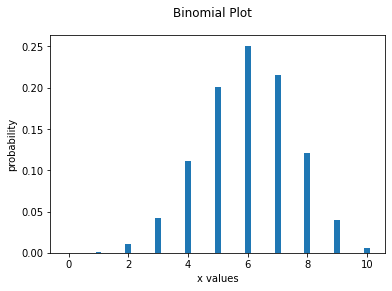

```python
binomplot(10,.6)   # run the binomplot function above first
```

Example: Graph a Binomial Probability Distribution with n=10 and p=.3.

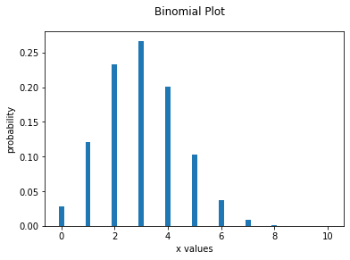

```python
binomplot(10,.3)    # run the binomplot function above first
```

# 9. Continuous Probability Distributions

Let $f(x)$ be the probability distribution of a continuous random variable $x$. Then the probability that $a < x < b$ corresponds to the area under the curve $y = f(x)$ between $a$ and $b$.

## 9.1 Uniform Distribution

The uniform probability distribution with minimum min and maximum max is given by:

$f(x)=\frac{1}{max-min}$ for $min<x<max$

- probability $P(a<x<b)=\frac{b-a}{max-min}$ area under $f(x)$ from $a$ to $b$
- mean or $E(x)=\frac{min+max}{2}$ and
- standard deviation is $\sigma(x)=\sqrt{\frac{(max-min)^2}{12}}$

The syntax for cumulative probability, $P(X<x)$, inverse, mean and standard deviation:

```
from scipy import stats
stats.uniform.cdf(x,min,max-min)  # cumulative prob P(X<x)
stats.uniform.ppf(p,min,max-min)  # inverse of cdf or percentiles
stats.uniform.mean(min,max-min)   # mean of X
stats.uniform.std(min,max-min)    # std of X
```

Example: The amount of time, in minutes, that a person waits for a bus, in a bus station, is uniformly distributed between zero and 15 minutes, inclusive.

- What is the probability that a person waits fewer than 12.5 minutes?

$P(X<12.5)=\text{stats.uniform.cdf}(12.5,0,15)$

```python
from scipy import stats
stats.uniform.cdf(12.5,0,15)
```

```
0.8333333333333334
```

Interpretation: The probability of waiting less than 12.5 minutes is 0.8333333333333334

Example: The amount of time, in minutes, that a person waits for a bus, in a bus station, is uniformly distributed between zero and 15 minutes, inclusive.

```python
stats.uniform.mean(0,15)   # mean
```

```
7.5
```

Interpretation: The mean waiting time is 7.5

```python
stats.uniform.std(0,15)  # std
```

```
4.330127018922194
```

Interpretation: The mean waiting time is 7.5 with a standard deviation of 4.33.

Example: The amount of time, in minutes, that a person waits for a bus is uniformly distributed between zero and 15 minutes, inclusive.

- Ninety percent of the time, the length of time a person must wait falls below what value?

$90^{th}\text{ percentile = stats.uniform.ppf}(.9,0,15)$

```python
stats.uniform.ppf(.9,0,15)
```

```
13.5
```

Interpretation: Ninety percent of the waiting time is less than or equal to 13.5

## 9.2 Normal Probability Distribution

The **normal** probability distribution with mean $\mu$ and standard deviation $\sigma$ is given by:

$f(x)=\frac{1}{\sigma\sqrt{2\pi}} e^{-\frac{(x-\mu)^2}{2\sigma^2}}$ It is bell shaped and is symmetric about the mean $\mu$.

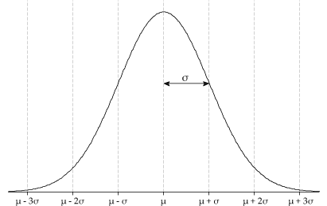

The syntax for the normal cumulative probability $P(X<x)$ with $\mu$=mean and $\sigma$=std is:

```
from scipy import stats
stats.norm.cdf(x,mean,std)
```

The syntax for inverse normal or p$^{th}$ percentile (with area to the left of p) and $\mu$=mean and $\sigma$=std is:

```
from scipy import stats
stats.norm.ppf(p,mean,std)
```

**Note**: The **standard normal distribution** has a mean $\mu$ of zero and standard deviation $\sigma$ of one.

Example: In a standard normal distribution what is the probability that the z value is less than 2?

[Watch demo video](https://youtu.be/eWrY4XUDQAI)

```python
from scipy import stats
stats.norm.cdf(2,0,1)    #for standard normal mean is zero and std is one
```

```
0.9772498680518208
```

Interpretation: $P(z<2)=0.9772498680518208$

Example: In a standard normal distribution what is the probability that the z value is between -2 and 2.

$P(-2<z<2)=P(z<2)-P(z<-2)$

=`stats.norm.cdf(2,0,1)-stats.norm.cdf(-2,0,1)`

```python
from scipy import stats
stats.norm.cdf(2,0,1)-stats.norm.cdf(-2,0,1)
```

```
0.9544997361036416
```

Interpretation: $P(-2<z<2)=0.9544997361036416$

Example: The midterm exam scores in a math class is normally distributed with a mean of 73 and a standard deviation of 5.

- Find the probability that a randomly selected student scored more than 65 on the exam.

$P(X>65)=1 - P(X<65)$ =`1-stats.norm.cdf(65,73,5)`

[Watch demo video](https://youtu.be/BVfWZR_1cK0)

```python
from scipy import stats
1-stats.norm.cdf(65,73,5)
```

```
0.945200708300442
```

Interpretation: $P(X>65)=0.945200708300442$

Example: The midterm exam scores in a math class is normally distributed with a mean of 73 and a standard deviation of 5.

- Find the probability that a randomly selected student scored less than 85.

$P(X<85)$=`stats.norm.cdf(85,73,5)`

```python
from scipy import stats
stats.norm.cdf(85,73,5)
```

```
0.9918024640754038
```

Interpretation: $P(X<85)=0.9918024640754038$

Example: The midterm exam scores in a math class is normally distributed with a mean of 73 and a standard deviation of 5.

- Find the 90th percentile (that is, find the score k that has 90% of the scores below k and 10% of the scores above k).

$90^{th} \text{percentile}$ = `stats.norm.ppf(.9,73,5)`

[Watch demo video](https://youtu.be/2e2CJJlih-Y)

```python
from scipy import stats
stats.norm.ppf(.90,73,5)
```

```
79.407757827723
```

Interpretation: Ninety percent of scores are less than or equal to 79.407757827723

Example: The midterm exam scores in a math class is normally distributed with a mean of 73 and a standard deviation of 5.

- Find the probability that a randomly selected student has a score between 70 and 90.

$P(70 < X < 90) = P(X<90) - P(X<70)$

```python
stats.norm.cdf(90,73,5) - stats.norm.cdf(70,73,5)
```

```
0.7254099529842495
```

Interpretation: $P(70<X<90)=0.7254099529842495$

**SciPy.Stats Summary of Probability Distributions**

```
from scipy import stats
```

| procedure | scipy.stats |
| --- | --- |
| Binomial pdf $P(X=x)$ | `stats.binom.pmf(k,n,p)` |
| Binomial cdf $P(X\le x)$ | `stats.binom.cdf(k,n,p)` |
| Normal cdf $P(X\le x)$ | `stats.norm.cdf(x,mean,std)` |
| Inverse Normal or p-th Percentile | `stats.norm.ppf(p,mean,std)` |
| *t* distribution cdf $P(X \le x)$ | `stats.t.cdf(t,df,0,1)` |
| Inverse *t* or p-th Percentile | `stats.t.ppf(p,df,0,1)` |
| chi-square cdf $P(\chi^2 \le ch2)$ | `stats.chi2.cdf(ch2,k-1)` |
| Inverse chi-square or p-th Percentile | `stats.chi2.ppf(p,k-1)` |

## 9.3 Central Limit Theorem

[Watch demo video](https://youtu.be/TonM6M-MQJA)

The sampling distribution of the sample mean is the probability distribution for the possible values of the mean that results when random sample of size n are repeatedly drawn from the population with mean $\mu$ and standard deviation $\sigma$.

When the sample size is large or the samples are drawn from a population that is normally distributed with mean $\mu$ and standard deviation $\sigma$, the sampling distribution of the sample mean $\bar{x}$ is approximately normal with mean $\mu$ and standard deviation of $\frac{\sigma}{\sqrt{n}}$

Example: A normally distributed population has a mean of 90 and a standard deviation of 15. Samples of size n = 25 are drawn randomly from the population and the mean is computed.

- Find the probability that sample mean is less than 85.

$P(\bar{x}<85)=$`stats.norm.cdf(85,90,15/25**.5)`

```python
from scipy import stats
stats.norm.cdf(85,90,15/25**(1/2))
```

```
0.0477903522728147
```

Interpretation: $P(\bar{x} <85)=0.0477903522728147$

Example: A normally distributed population has a mean of 90 and a standard deviation of 15. Samples of size n = 25 are drawn randomly from the population and the mean is computed.

- Find the probability that the sample mean is between 85 and 92.

$P(85<\bar{x}<92)=P(\bar{x}<92)-P(\bar{x}<85)$

$=stats.norm.cdf(92,90,\frac{15}{\sqrt{25}})-stats.norm.cdf(85,90,\frac{15}{\sqrt{25}})$

```python
from scipy import stats
stats.norm.cdf(92,90,15/25**.5)-stats.norm.cdf(85,90,15/25**.5)
```

```
0.6997171101802624
```

Interpretation: $P(85 < \bar{x} <92)=0.6997171101802624$

Example: The mean age of tablet device users is 34 years. Suppose the standard deviation is 15 years. If a random sample of size n = 100 is drawn from this population:

- Find the probability that the sample mean age is more than 30 years.
- Find the 95th percentile for the sample mean age.

$P(\bar{x}>30)=1-P(\bar{x}<30)=1-\text{stats.norm.cdf}(30,34,\frac{15}{\sqrt{100}})$

```python
from scipy import stats
1-stats.norm.cdf(30,34,15/100**.5)
```

```
0.9961696194324102
```

Interpretation: $P(\bar{x}>30)=0.9961696194324102$

$95^{th}\text{ percentile = stats.norm.ppf}(.95,34,\frac{15}{\sqrt{100}})$

```python
from scipy import stats
stats.norm.ppf(.95,34,15/100**.5)
```

```
36.46728044042721
```

Interpretation: Ninety-five percent of the sample means are less than or equal to 36.46728044042721

**Example**

The average score for an IQ test is 100 with a standard deviation of 15. Assume the test scores are normally distributed.

1. If a random sample of 25 test scores is selected from this population, what is the probability that the sample mean is between 90 and 110.
2. Find the 95th percentile for the sample mean score.

```python
from scipy import stats
stats.norm.cdf(110,100,15/(25**.5))-stats.norm.cdf(90,100,15/(25**.5))
```

```
0.9991418793336064
```

Interpretation: The probability that the mean is between 90 and 110 is 0.9991418793336064. That is, $P(90<\bar{x}<110)=0.9991418793336064$

```python
from scipy import stats
stats.norm.ppf(.95,100,15/(25**.5))
```

```
104.93456088085442
```

Interpretation: 95 percent of the test scores are less than or equal to 104.93456088085442.

# 10. Confidence Intervals

**Inferential statistics** deals with making inferences about a population parameter using information contained in the sample. Estimation and Hypothesis testing are two types of inferential statistics. There are two types of estimation: point and interval estimation.

1. The sample mean $\bar x$ is a point estimate of the population mean $\mu$
2. The sample proportion $\hat{p}$ is a point estimate of the population proportion $p$.

An **interval estimate** or **confidence interval** provides two values, where all real numbers between these values are considered as an estimate to the population parameter.

1. $(\bar{x}-E,\bar{x}+E)$ interval estimate of the mean $\mu$
2. $(\hat{p}-E,\hat{p}+E)$ interval estimate of the proportion $p$

## 10.1 Confidence Interval for Mean $\mu$ (z distribution)

[Watch demo video 1](https://youtu.be/dD-zqdPimPc)

[Watch demo video 2](https://youtu.be/7-EwCrL1zb8)

Consider a random sample size of $n$ from a population with an unknow mean $\mu$ and known standard deviation $\sigma$. To construct an interval estimate of the population mean $\mu$ with $(1-\alpha)100\%$ confidence, use the following:

$C = 1 - \alpha$ (the confidence level)

$E = z_{\frac{\alpha}{2}}\frac{\sigma}{\sqrt n}$ (the Margin of Error)

$\bar{x} - E < \mu < \bar{x} + E$ (the confidence interval)

For large sample size the sample standard deviation can be used for the population standard deviation $\sigma$.

Use scipy.stats for obtaining the value of $z_{\frac{\alpha}{2}}$ where $C=1-\alpha$ as follows:

```
from scipy import stats
stats.norm.ppf(C+(1-C)/2,mean,std)
```

### Margin of Error for $\mu$ (summary statistics given)

To find the margin of error for estimating the population mean when summary statistics such as the sample size and population standard deviation are given, use the `error_z_mean` function below with arguments: confidence level C, Population standard deviation std and sample size n.

$E = z_{\frac{\alpha}{2}}\frac{\sigma}{\sqrt n}$

```python
# Margin of Error, given confidence level C, std, n
def error_z_mean(C,std,n):
  from scipy import stats
  er = (std/n**.5)*stats.norm.ppf(C+(1-C)/2,0,1)
  return print("The Margin of Error is",er)
```

Or you can use the code below by substituting `std, n` and `C`:

```
from scipy import stats
error = (std/n**.5)*stats.t.ppf(C+(1-C)/2,n-1,0,1)
```

Example: Midterm exam scores are normally distributed with an unknown population mean and a population standard deviation of three points. A random sample of 40 scores has mean of 72. Find a 90% margin of error and the confidence interval estimate for the population mean exam score.

- Find the margin of error for estimating the population mean.

We use the `error_z_mean` function above with arguments: C = 0.9, std = 3, n = 40.

1. Click `play` button in the above code `def error_z_mean(C,std\,n)`
2. Click `+ Code`
3. Type `error_z_mean(.90,3,40)

```python
error_z_mean(.90,3,40)
```

```
The Margin of Error is 0.780222581813336
```

### Confidence Interval for $\mu$ (summary statistics given)

To find the confidence interval for the population mean when summary statistics such as the sample size, mean and populaton standard deviation are given, use the `conf_z_mean` function below with arguments: confidence level C, mean, std, and n.

```python
# Confidence interval, given confidence level C, std, n
def conf_z_mean(C,mean,std,n):
     from scipy import stats
     ebm = (std/n**.5)*stats.norm.ppf(C+(1-C)/2,0,1)
     return print("(", mean-ebm, ",", mean+ebm, ')')
```

Example: Midterm exam scores are normally distributed with an unknown population mean and a population standard deviation of three points. A random sample of 40 scores has mean of 72. Find a 90% confidence interval estimate for the population mean exam score.

- Find a 90% confidence interval for the true (population) mean of the exam scores.

We use the `conf_z_mean` function above with arguments: C = 0.9, mean = 72, std = 3, n = 40.

```python
conf_z_mean(.90,72,3,40)
```

```
( 71.21977741818667 , 72.78022258181333 )
```

Interpretation: $71.21977741818667 < \mu < 72.78022258181333$

## 10.2 Confidence Interval for Mean $\mu$ (*t* Distribution)

[Watch demo video](https://youtu.be/dI84UpncMvw)

Consider a random sample of $n$ from a population with an unknow mean $\mu$ and unknown standard deviation $\sigma$. To construct an interval estimate of the population mean $\mu$ with $(1-\alpha)100\%$ confidence, use the following: Confidence level, $C=1-\alpha$

$C=1-\alpha$ (level of confidence)

$E=t_{\frac{\alpha}{2}} \times \frac{s}{\sqrt{n}}$ (Margin of Error)

$\bar{x} - E < \mu < \bar{x}+E$ (confidence interval)

scipy.stats to obtain the value of $t_{\frac{\alpha}{2}}$

```
from scipy import stats
stats.t.ppf(C+(1-C)/2,n-1,0,1)  # df=n-1
```

Note: When the sample size is large, the t-distribution is robust when the shape of the distribution is not normal.

### Margin of Error for $\mu$ (t-distribution summary stats given)

To find the margin of error to estimate the population mean when summary stats is given, use the function `error_t_mean` below with arguments: level of confidence C, std and n. Here the population is assumed to be normal.

$E=t_{\frac{\alpha}{2}} \frac{s}{\sqrt{n}}$

```python
# margin of error given the level of confidence C, mean, std and n
def error_t_mean(C,std,n):
    from scipy import stats
    ebm = (std/n**.5)*stats.t.ppf(C+(1-C)/2,n-1,0,1)
    return print("Margin of Error is",ebm)
```

You can also use the code below by substituting `std, n` and `C`:

```
from scipy import stats
error = (std/n**.5)*stats.t.ppf(C+(1-C)/2,n-1,0,1)
```

```python
# Option 1

from scipy import stats
C = .95
std = 1.72
n = 15

error = (std/n**.5)*stats.t.ppf(C+(1-C)/2,n-1,0,1)
error
```

```
0.9525042514911835
```

```python
# Option 2
error_t_mean(.95, 1.72, 15)
```

```
Margin of Error is 0.9525042514911835
```

Interpretation: In both cases, the margin of error is 0.9525042514911835.

To find the confidence interval for estimating the population mean when summary stats is given you can subtract and add the margin of error from above to the mean or use the function `conf_t_mean` below with arguments: level of confidence C, mean, std and n. Here the population is assumed to be normal.

```python
# confidence interval given level of confidence C and x

def conf_t_mean(C,mean,std,n):
    from scipy import stats
    ebm = (std/n**.5)*stats.t.ppf(C+(1-C)/2,n-1,0,1)
    print ('mean is',mean,'and std is',std)
    return print("(", mean-ebm, ",", mean+ebm, ')' )
```

## Confidence Interval for $\mu$ (raw data given)

To find the confidence interval and margin of error for the population mean when raw data is given, first find the sample mean, std and size using numpy.

Example: In a study of a new pain relieving drag, the measures of pain levels for 15 subjects are recorded below. Use the sample data to construct a 95% confidence interval for the mean pain levels for the population (assume normal).

```
8.6; 9.4; 7.9; 6.8; 8.3; 7.3; 9.2; 9.6; 8.7; 11.4; 10.3; 5.4;
                  8.1; 5.5; 6.9
```

- Find the margin of error for 95% confidence interval

We will use the `error_t_mean` function above. But first we need the sample std and size.

```python
x = [8.6, 9.4, 7.9, 6.8, 8.3, 7.3, 9.2, 9.6, 8.7, 11.4, 10.3, 5.4, 8.1,
             5.5, 6.9]

import numpy as np
s = np.std(x,ddof=1)
n = np.size(x)

print('std',s)
print('size',n)
```

```
std 1.6722383060978339
size 15
```

```python
error_t_mean(.95,s,n)  # values of s and n from above
```

```
Margin of Error is 0.9260547070143034
```

Example: In a study of a new pain relieving drag, the measures of pain levels for 15 subjects are recorded below. Use the sample data to construct a 95% confidence interval for the mean pain levels for the population (assume normal).

```
8.6; 9.4; 7.9; 6.8; 8.3; 7.3; 9.2; 9.6; 8.7; 11.4; 10.3; 5.4;
                  8.1; 5.5; 6.9
```

- Find the 95% confidence interval for the mean

use the `conf_t_mean` function above but first find the mean, std and n.

```python
x = [8.6, 9.4, 7.9, 6.8, 8.3, 7.3, 9.2, 9.6, 8.7, 11.4, 10.3, 5.4, 8.1,
             5.5, 6.9]

import numpy as np
m = np.mean(x)
s = np.std(x,ddof=1)
n = np.size(x)
```

Call the function `conf_t_mean` with mean = m, std = s using results from the above code.

```python
conf_t_mean(.95,m,s,n) # values of m,s and n from above
```

```
mean is 8.226666666666667 and std is 1.6722383060978339
( 7.300611959652363 , 9.15272137368097 )
```

Interpretation: $7.300611959652363 < \mu < 9.15272137368097$

## 10.3 Confidence Intervals for Proportion $p$ (z-distribution)

Suppose a random sample of $n$ (identical trials) is selected from a population with probability of success, $p$. The $(1-\alpha)100\%$ confidence interval is given by:

$C = 1 - \alpha$ (Confidence level)

$E = z_{\frac{\alpha}{2}}\sqrt{\frac{\hat p \hat q}{n}}$ (Margin of Error)

$\hat{p}-E < P < \hat{p}+E$ (Confidence interval)

### Confidence Interval and Margin of Error for $p$

[Watch demo video](https://youtu.be/xrQgvMDmECU)

To find the confidence interval for the population proportion when summary statistics such as number of success in the sample and sample size, use the function `conf_prop` below with arguments: confidence level C, number of success and sample size n.

$E = z_{\frac{\alpha}{2}}\sqrt{\frac{\hat p \hat q}{n}}$

$\hat{p} = \frac{x}{n}=$p is the sample proportion

```python
# confidence interval and margin of error given sample proportion p and n

def conf_prop(C,p,n):
  from scipy import stats
  eb1 = ((p*(1-p)/n)**.5)*stats.norm.ppf(C+(1-C)/2,0,1)
  return print(" Sample Proportion =",p,"\n Margin of Error = ", eb1,
               "\n Confidence Interval","(",p - eb1,",",p + eb1,")")
```

Or you can use the code below by substituting p = x/n for the sample proportion and n sample size.

```
error = ((p*(1-p)/n)**.5)*stats.norm.ppf(C+(1-C)/2,0,1)
```

Example: In a random sample of 35 students in a college, 20% are registered to vote. Construct the 90% confidence interval for the proportion of all students in the college registered to vote.

Use the `conf_prop` function with arguments: C=.9, p=.2 and n=35.

```python
conf_prop(.90,.2,35)
```

```
 Sample Proportion = 0.2
 Margin of Error =  0.11121240329789352
 Confidence Interval ( 0.0887875967021065 , 0.3112124032978935 )
```

Example: In a random sample of 35 students in a college, 20 are registered to vote. Construct the 95% confidence interval for the proportion of all students in the college registered to vote.

Before we use the `conf_prop` we need to find the sample proportion p=x/n = 20/35

```python
p = 20/35
p
```

```
0.5714285714285714
```

Now call the function with C = .95, p = 0.5714285714285714 and n = 35

```python
conf_prop(.95,0.5714285714285714,35)
```

```
 Sample Proportion = 0.5714285714285714
 Margin of Error =  0.16394819961335458
 Confidence Interval ( 0.4074803718152168 , 0.735376771041926 )
```

### Calculating the Sample Size $n$

**Sample Size for Estimating Proportions, *p***

$n=p(1-p)*[\frac{z_{\frac{\alpha}{2}}}{E}]^2$

To calculate the minimum sample size $n$ for a given level of confidence C, estimated proportion p and margin of error E, use the function `samp_pro` below. p=.5 when no estimates are available.

```python
def samp_pro(C,p,E):
  from scipy import stats
  sam = p*(1-p)*stats.norm.ppf(C+(1-C)/2,0,1)**2/E**2
  return print("sample size = ", sam)
```

Example: Suppose city officials want to determine the current percentage of residents vaccinated for Covid19. How many residents should the city officials survey in order to be 90% confident that the estimated (sample) proportion is within three percentage points of the true population proportion of residents who are vaccinated for Covid19?

use the `samp_pro` function above with arguments: C = 0.90, p = 0.5 (none is given), E = 0.03.

```python
samp_pro(.90,.5,.03)
```

```
sample size =  751.5398483598369
```

Interpretation: 752 (always round up) residents are needed.

**Sample Size for Estimating Mean, $\mu$**

$n=[\frac{\sigma\times z_{\frac{\alpha}{2}}}{E}]^2$

To calculate the minimum sample size $n$ for a given level of confidence C, standard devation $\sigma$ as s and margin of error E, use the function `samp_mean` below.

```python
def samp_mean(C,s,E):
  from scipy import stats
  sam = (s*stats.norm.ppf(C+(1-C)/2,0,1)/E)**2
  return print("sample size = ", sam)
```

```python
samp_mean(.95,15,3)
```

```
sample size =  96.03647051735315
```

```python
samp_mean(0.9,15,3)
```

```
sample size =  67.63858635238533
```

Interpretation: 68 (round up) students are needed in the random sample.

# 11. Hypothesis Testing

Hypothesis testing involves making decisions on a **claim** or statement made about the value of population parameter.

First, the claim is used to define the null $H_o$ and alternative $H_a$ hypotheses. The alternative hypothesis is used to determine if the test is left (smaller), right (greater) or two-tailed test. A test-statistic and p-value are calculated with the assumption that the null hypothesis is true. A significant level or rejection region can be used to make a decision about the null-hypothesis.

## 11.1 Hypothesis Testing for Mean $\mu$ (z-test)

[Watch demo video](https://youtu.be/wIScbXXtbQg)

Suppose a random sample of size $n$ is drawn from a population with unknow mean $\mu$ and either the standard deviation $\sigma$ is given or the sample size is large.

To test a hypothesis about the mean $\mu$ of the form:

$H_0:\mu =\mu_0$

$H_a:\mu < \mu_0$ `smaller`

OR:

$H_0:\mu =\mu_0$

$H_a:\mu > \mu_0$ `greater`

OR:

$H_0:\mu =\mu_0$

$H_a:\mu \ne \mu_0$ `two-sided`

we use the following test-statistic

$z=\frac{\bar x - \mu_o}{\frac{\sigma}{\sqrt{n}}}$

Use the function `z_test_mean` below with arguments: null_mean = $\mu_o$, sigma = $\sigma$, sample_mean = $\bar{x}$, n, alternative = 'smaller' OR 'greater' OR 'two-sided'. By default it is set to 'two-sided'.

```python
# z test with alternative 'smaller' or 'greater' or 'two-sided'
def z_test_mean(null_mean,sigma,sample_mean,n,alternative='two-sided'):
    from scipy import stats
    z = (sample_mean-null_mean)/(sigma/n**.5)
    if alternative == 'smaller':
        pv = stats.norm.cdf(z,0,1)
    elif alternative == 'greater':
        pv = 1-stats.norm.cdf(z,0,1)
    elif alternative == 'two-sided':
        if z< 0:
            pv = 2*stats.norm.cdf(z,0,1)
        else: pv = 2*(1-stats.norm.cdf(z,0,1))
    else:
        print("alternative option error")
    return print("z test statistic = ", z, "and p-value = ",pv)
```

Example: The president of a company claims that the average number of minutes employees waste time surfing the internet is more than 100 minutes a day. The population number of hours wasted is normally distributed with standard deviation of 10 minutes. A random sample of 19 employees from this company has a mean of 105 minutes. Do this sample data provide evidence that the mean wasted time for this company is more than 100 minutes? Use $\alpha = 0.05$.

$H_o:\mu = 100$

$H_a: \mu > 100$

Use the `z_test_mean` function above with arguments: null_mean = 100, sigma = 10, sample_mean = 105, n = 19, alternative = 'greater' (more than 100).

1. Click `play` button on code above `def z_test_mean`
2. Click `+ Code`
3. Type `z_test_mean(100,10,105,19,'greater`)
4. Click `play` button

```python
z_test_mean(100,10,105,19,'greater')
```

```
z test statistic =  2.179449471770337 and p-value =  0.014649147202275281
```

Interpretation: p-value = 0.014649 < $\alpha$= 0.05. The null hpypothesis is rejected.

Alternatively, compare `z = (sample_mean-null_mean)/(sigma/n**.5)` with the critical z `stats.norm.ppf(1-.05,0,1) = 1.6448` see code below. $z=2.179449471770337>1.6448536269514722$ thus reject the null-hypothesis.

```python
from scipy import stats
stats.norm.ppf(1-0.05,0,1)   # right-tailed test
```

```
1.6448536269514722
```

Example: A government official claims that the average recovery time for Covid19 patients with severe symptoms is 6 weeks. A random sample of 23 patients with severe symptoms has a mean recovery time of 5.4 weeks with standard deviation of 1.1 weeks. Assume recovery time is normally distributed with standard deviation of 1.5 ($\sigma$) weeks. Test the government's official claim at $\alpha$ of 0.05. Use the `z_test_mean` function below.

```python
# z test with alternative 'smaller' or 'greater' or 'two-sided'
def z_test_mean(null_mean,sigma,sample_mean,n,alternative='two-sided'):
    from scipy import stats
    z = (sample_mean-null_mean)/(sigma/n**.5)
    if alternative == 'smaller':
        pv = stats.norm.cdf(z,0,1)
    elif alternative == 'greater':
        pv = 1-stats.norm.cdf(z,0,1)
    elif alternative == 'two-sided':
        if z< 0:
            pv = 2*stats.norm.cdf(z,0,1)
        else: pv = 2*(1-stats.norm.cdf(z,0,1))
    else:
        print("alternative option error")
    return print("z test statistic = ", z, "and p-value = ",pv)
```

`null_mean=6,sigma=1.5,sample_mean=5.4,n=23,alternative='two-sided`

```python
z_test_mean(6,1.5,5.4,23,'two-sided')
```

```
z test statistic =  -1.9183326093250865 and p-value =  0.05506885012079212
```

Example: The work week of a particular organization workers is normally distributed with a mean of 47 hours. A newly hired manager at this company believes that employees average work hours is **different** from 47. She randomly asks 12 workers for the lengths in hours of their work week. Their responses are shown below. Test the claim using a 10% level of significance. The population standard deviation is 5.

Hours: `46, 43, 55, 50, 46, 67, 48, 47, 48, 49, 55, 54`

$H_o:\mu = 47$

$H_a: \mu \ne 47$

We need to find the mean and sample size of the data before we call the function, `z_test_mean`.

```python
import numpy as np
x = [46, 43, 55, 50, 46, 67, 48, 47, 48, 49, 55, 54]

m = np.mean(x)
n = np.size(x)
print('mean is',m,'\n n is',n)
```

```
mean is 50.666666666666664
 n is 12
```

Using the `sample_mean=m` and n from the above code, we call `z_test_mean` with arguments:`47,5,50.666667,12,'two-sided'`. But by default the function is set to 'two-sided'

```python
z_test_mean(47,5,50.6666667,12)   #you need to run the ttestmean function above first before you call it.
```

```
z test statistic =  2.540341207528364 and p-value =  0.011074436944822352
```

## 11.2 Hypothesis Testing for Mean $\mu$ (t-test)

[Watch demo video](https://youtu.be/peTRJx_LsUo)

Suppose a random sample of size $n$ is drawn from a population that is approximately normal with unknow mean $\mu$ and unknow standard deviation $\sigma$. To test a hypothesis about the mean $\mu$ of the form:

$H_0:\mu =\mu_0$

$H_a:\mu < \mu_0$ `smaller`

OR:

$H_0:\mu =\mu_0$

$H_a:\mu > \mu_0$ `greater`

OR:

$H_0:\mu =\mu_0$

$H_a:\mu \ne \mu_0$ `two-sided`

we use the following test-statistic (t-distribution)

$t=\frac{\bar x - \mu_o}{\frac{s}{\sqrt{n}}}$

We use the `t_test_mean` function with arguments: null_mean = $\mu_o$, sample mean = sample_mean, sample standard deviation = sample_std, sample size n and alternative:'smaller', 'greater' or 'two-sided' for two sided test.

```python
# t test with alternative being 'smaller' or 'greater' or 'two-sided'
def t_test_mean(null_mean,sample_mean,sample_std,n,alternative='two-sided'):
    from scipy import stats
    t = (sample_mean-null_mean)/(sample_std/n**.5)
    if alternative == 'smaller':
        pv = stats.t.cdf(t,n-1,0,1)
    elif alternative == 'greater':
        pv = 1-stats.t.cdf(t,n-1,0,1)
    elif alternative == 'two-sided':
        if t< 0:
            pv = 2*stats.t.cdf(t,n-1,0,1)
        else: pv = 2*(1-stats.t.cdf(t,n-1,0,1))
    else:
        print("alternative option syntax error")
    return print("t test statistic = ", t, " p-value = ",pv)
```

Example: College administrators believe that the midterm exam score for Social Studies students is 70. A Social Studies instructor thinks the mean score is **lower** than 70. He samples ten students and obtains the scores `65; 65; 70; 67; 66; 63; 63; 68; 72; 71`. Performs a hypothesis test using a 5% level of significance. The data are assumed to be from a normal distribution.

$H_o: \mu=70$

$H_a: \mu < 70$

Use the `t_test_mean` function above. But first we have to find the sample mean and standard deviation from the data.

```python
import numpy as np
x = [65, 65, 70, 67, 66, 63, 63, 68, 72, 71]
sample_mean = float(np.mean(x))
sample_std = float(np.std(x,ddof=1))
n = len(x)
print('sample mean is',sample_mean,'sample std is',sample_std,'n is',n)
```

```
sample mean is 67.0 sample std is 3.197221015541813 n is 10
```

```python
t_test_mean(70,67.0,3.1972,10,"smaller")   #you need to run the ttestmean function above first
```

```
t test statistic =  -2.9672316340876823  p-value =  0.007886584766274029
```

Interpretation: p-value < $\alpha=0.05$, reject the null. Or compare the t test statistics with t critical `stats.t.ppf(.05/2,n-1,0,1)` = -2.26 (see code below)

```python
from scipy import stats
stats.t.ppf(.05/2,10-1,0,1)
```

```
-2.262157162740992
```

Example: A college administrator claims that the average grade point for all students in the college is greater than 3.0. A random sample of 20 students has a sample mean of 3.4 with standard deviation of 0.8. Assume average grade points are normally distributed. Test the college administrator's claim at $\alpha$ of 0.10. Use the `t_test_mean` function below.

```python
# t test with alternative being 'smaller' or 'greater' or 'two-sided'
def t_test_mean(null_mean,sample_mean,sample_std,n,alternative='two-sided'):
    from scipy import stats
    t = (sample_mean-null_mean)/(sample_std/n**.5)
    if alternative == 'smaller':
        pv = stats.t.cdf(t,n-1,0,1)
    elif alternative == 'greater':
        pv = 1-stats.t.cdf(t,n-1,0,1)
    elif alternative == 'two-sided':
        if t< 0:
            pv = 2*stats.t.cdf(t,n-1,0,1)
        else: pv = 2*(1-stats.t.cdf(t,n-1,0,1))
    else:
        print("alternative option syntax error")
    return print("t test statistic = ", t, " p-value = ",pv)
```

`null_mean=3,sample_mean=3.4,sample_std=0.8,n=20,alternative='greater'`

```python
t_test_mean(3,3.4,0.8,20,'greater')
```

```
t test statistic =  2.2360679774997894  p-value =  0.01877027477426252
```

Interpretation: Since the p-value 0.01877027477426252 is less than $\alpha=$ 0.1, reject the null hypothesis. There is enough evidence to support the administrator's claim.

### Proportions

The sample proportion is defined as the number of individuals in the sample with the specified characteristic, x, divided by the sample size, n.

$\hat{p}=\frac{x}{n}$

The population proportion is defined as the number of individuals in the population with the specified characteristic, x, divided by the population size, N.

$p=\frac{x}{N}$

Example: 20 students were asked if they were registered to vote. Their responses are listed below. Find the proportion of YES'.

```
NO, NO, YES, YES, NO, YES, NO, NO, YES, NO, YES, NO, NO, YES,
                  YES, YES, YES, NO, YES, YES
```

```python
x = ['NO', 'NO', 'YES', 'YES', 'NO', 'YES', 'NO', 'NO', 'YES', 'NO',
             'YES', 'NO', 'NO', 'YES', 'YES', 'YES', 'YES', 'NO', 'YES', 'YES']
x_df = pd.DataFrame({'vote':x})
x_df.value_counts()
```

```
vote
YES     11
NO       9
dtype: int64
```

```python
x_df.value_counts(normalize=True)
```

```
vote
YES     0.55
NO      0.45
dtype: float64
```

```python
proportion = 11/20  # here yes is counted as "success"
print("proportion is",proportion)
```

```
proportion is 0.55
```

## 11.3 Hypothesis Testing for Proportion $P$ (z-test)

[Watch demo video](https://youtu.be/-PfIKcXcOSw)

Suppose a random sample of $n$ (identical trials) is drawn from a population with probability of success $p$. The sample proportion, $\hat{p}$, has approximately normal distribution with mean $p$ and standard deviation of $\sqrt{p(1-p)/n}$ for large $n$.

To test a hypothesis of the form:

$H_0:p =p_0$

$H_a:p < p_0$ `smaller`

OR:

$H_0:p =p_0$

$H_a:p > p_0$ `greater`

OR:

$H_0:p =p_0$

$H_a:p \ne p_0$ `two-sided`

use the following test-statistics (z-distribution)

$z=\frac{\hat p - P_o}{\sqrt{\frac{P_o(1-P_o)}{n}}}$

### Hypothesis Testing for Proportions $p$ (raw data given)

```python
def z_test_prop(null_prop,x,n,alternative='two-sided'):
    from scipy import stats
    p = x/n
    z = (p-null_prop)/(null_prop*(1-null_prop)/n)**.5
    if alternative == 'smaller':
        pv = stats.norm.cdf(z,0,1)
    elif alternative == 'greater':
        pv = 1-stats.norm.cdf(z,0,1)
    elif alternative == 'two-sided':
        if z< 0:
            pv = 2*stats.norm.cdf(z,0,1)
        else: pv = 2*(1-stats.norm.cdf(z,0,1))
    else:
        print("altrnative option syntax error")
    return print("z test statistic = ", z, " p-value = ",pv)
```

Example: The president believes than 65% of voters approve his job performance. A pollster performs a hypothesis test to determine if the percentage is the same or different from 65%. She samples 100 voters and 61 reply that they approve the president's performance. Test the hypothesis at 1% level of significance.

$H_o:p=0.65$ vs $H_a:p \ne 0.65$

```python
z_test_prop(0.65,61,100,'two-sided')
```

```
z test statistic =  -0.8386278693775355  p-value =  0.4016781664697726
```

Interpretation: p-value > $\alpha=0.01$, fail to reject the null

Example: The college president claims that the proportion of students registered to vote is more than 55%. A random sample of 20 students were asked if they are registered to vote. The results are listed below. Test the president's claim at 10% level of significance.

```
NO, NO, YES, YES, NO, YES, NO, NO, YES, NO, YES, NO, NO, YES,
                  YES, YES, YES, NO, YES, YES
```

Before we use the `z_test_porp` function, we need to find x (the number of success). We can use the `x_df.value_count()' to find x.

```python
x = ['NO', 'NO', 'YES', 'YES', 'NO', 'YES', 'NO', 'NO', 'YES', 'NO',
             'YES', 'NO', 'NO', 'YES', 'YES', 'YES', 'YES', 'NO', 'YES', 'YES']
x_df = pd.DataFrame({'vote':x})
x_df.value_counts()
```

```
vote
YES     11
NO       9
dtype: int64
```

```python
z_test_prop(.55,11,20,'greater')
```

```
z test statistic =  0.0  p-value =  0.5
```

### Hypothesis Testing for Proportions $p$ (summary stats given)

Hypothesis testing when raw data such as sample size, proportion are given, use the `z_test_stats` function below with arguments: null_prop, p, n, alternative.

```python
# z proportion test ,altenative can only be "left" or "right" or "two"

def z_test_prop_stats(null_prop,p,n,alternative):
    from scipy import stats
    z = (p-null_prop)/(null_prop*(1-null_prop)/n)**.5
    if alternative == 'left':
        pv = stats.norm.cdf(z,0,1)
    elif alternative == 'right':
        pv = 1-stats.norm.cdf(z,0,1)
    elif alternative == 'two':
        if z< 0:
            pv = 2*stats.norm.cdf(z,0,1)
        else: pv = 2*(1-stats.norm.cdf(z,0,1))
    else:
        print("altrnative option syntax error")
    return print("z test statistic = ", z, "and p-value = ",pv)
```

Example: The college president claims that the proportion of students registered to vote is more than 60%. A random sample of 50 students were asked if they are registered to vote. 62% were registered voters. Test the president's claim at 5% level of confidence.

$H_o:p=0.60$ vs $H_a:p>0.60$

Use the `z_test_prop_stats` function with arguments: null_prop=.60,p=.62,n=50,alternative='right'

```python
z_test_prop_stats(.6,.62,50,'right')
```

```
z test statistic =  0.28867513459481314 and p-value =  0.38641499634222365
```

Interpretation: p-value is not less than $\alpha=0.05$. Fail to reject the null hypothesis.

Example: The mayor of a city believes that more than 60% of the residents are fully vaccinated for Covid19. In a survey of 120 residents, 81 were fully vaccinated. Test the mayor's claim at $\alpha$ level of 0.05. Use the `z_test_prop` function below.

```python
def z_test_prop(null_prop,x,n,alternative):  #altenative can only be "smaller"
                                               # or "greater" or "two-sided"
    from scipy import stats
    p = x/n
    z = (p-null_prop)/(null_prop*(1-null_prop)/n)**.5
    if alternative == 'smaller':
        pv = stats.norm.cdf(z,0,1)
    elif alternative == 'greater':
        pv = 1-stats.norm.cdf(z,0,1)
    elif alternative == 'two-sided':
        if z< 0:
            pv = 2*stats.norm.cdf(z,0,1)
        else: pv = 2*(1-stats.norm.cdf(z,0,1))
    else:
        print("altrnative option syntax error")
    return print("z test statistic = ", z, " p-value = ",pv)
```

`z_test_prop(null_prop,x,n,alternative)` with `null_prop=.6,x=81,n=120,alternative='greater'`

```python
z_test_prop(.6,81,120,'greater')
```

```
z test statistic =  1.6770509831248437  p-value =  0.04676625634454645
```

Interpretation: Since the p-value 0.04676625634454645 is less than $\alpha$ of 0.05, reject the null hypothesis. There is enough evidence to support the mayor's claim.

# 12. Linear Regression and Correlation

How do we measure a relationship between two quantitative variables? For example, what is the relationship between studentsÃ¢â‚¬â„¢ time spent studying for a test and their test scores? In general, the more time spent studying (more hours) would yield a higher test score. There is a direct or positive relationship between time spent and test scores. But how strong is the relationship?

Another example is the relationship between the age (years) of a car and its price (in dollars). In general, the older the car (more years) the cheaper (less dollars) it costs. The relationship is indirect or negative. What type and how strong is the relationship?

## 12.1 Scatter plot

One way to check for a relationship between two variables is to draw a scatter plot. One of the variables (independent/explanatory) can be on the x-axis and the dependent(response) on the y-axis. To draw a scatterplot of two variables x and y use the following code

```
import matplotlib.pyplot as plt
x = [x1,x2,...]
y = [y1,y2,...]
plt.scatter(x, y)
```

## 12.2 The Pearson Correlation Coefficient

The (Pearson) correlation coefficient is a measure of the strength and direction of the *linear* relationship between two variables.

$\rho = \frac{cov(x,y)}{\sigma_x \sigma_y}$ for population correlation coefficient

$r=\frac{cov(x,y)}{s_x s_y}$ or $r=\frac{n\Sigma{xy}-\Sigma{x}\Sigma{y}}{\sqrt{n\Sigma{x^2}-(\Sigma{x})^2}\sqrt{n\Sigma{y^2}-(\Sigma{y})^2}}$ for sample correlation coefficient

Where $\rho$ and $r$ are the population and sample Pearson correlation coefficients respectively. $cov(x,y)$ is the covariance of the two variables.

The value of r is between -1 and 1 and it is unitless. That is, it is not affected by the unit of measurements of both variables.

1. if $r$ or $\rho$ is close to +1, we conclude strong positive relationship
2. If $r$ or $\rho$ is close to -1, we conclude strong negative relationship
3. If $r$ or $\rho$ is close to zero, we conclude weak or no relationship

To compute the correlation coefficient, you can use of the following two options.

```
from scipy import stats
stats.linregress(x, y)  # rvalue the 3rd from the output
```

or

```
import numpy as np
x = [x1,x2,...]
y = [y1,y2,...]
np.corrcoef(x,y)

returns a matrix form of correlations between x and x, x and y, y and x, y and y
```

Example: The midterm exam out of a total of 100 points, x, and final exam out of a total of 200 points, y, scores for a random sample of 11 students is listed below. Find the correlation coefficient and draw a scatter plot.

| x | 65 | 67 | 71 | 71 | 66 | 75 | 67 | 70 | 71 | 69 | 69 |  |
| --- | --- | --- | --- | --- | --- | --- | --- | --- | --- | --- | --- | --- |
| **y** | **145** | **133** | **185** | **163** | **126** | **198** | **153** | **163** | **159** | **151** | **159** |  |

[Watch demo video 1](https://youtu.be/fhgYqcvlx5k) Scatter Plot

[Watch demo video 2](https://youtu.be/TsRd7IVeelQ) Correlation Coefficient

```python
# Pearson Correlation Coefficient
import numpy as np
x = [65, 67, 71, 71, 66, 75, 67, 70, 71, 69, 69]
y = [145, 133, 185, 163, 126, 198, 153, 163, 159, 151, 159]
np.corrcoef(x,y)
```

```
array([[1.        , 0.87974511],
       [0.87974511, 1.        ]])
```

Interpretation: Because `r=0.879745` is positive and close to one, we can conclude that there is a strong and direct relationship between x midterm scores and y final exam scores.

**Note**: The correlation coefficient between x and x is 1. Similarly between y and y is 1.

```python
x = [65, 67, 71, 71, 66, 75, 67, 70, 71, 69, 69]
y = [145, 133, 185, 163, 126, 198, 153, 163, 159, 151, 159]

from scipy import stats
stats.linregress(x, y)
```

```
LinregressResult(slope=6.364142538975501, intercept=-282.5556792873051, rvalue=0.8797451071731136, pvalue=0.00035593568153235875, stderr=1.1464698617902889)
```

Interpretation: for now we only need the third output `rvalue=0.8797451071731136`

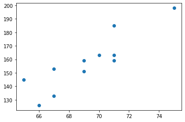

```python
# scatterplot
import matplotlib.pyplot as plt
x = [65, 67, 71, 71, 66, 75, 67, 70, 71, 69, 69]
y = [145, 133, 185, 163, 126, 198, 153, 163, 159, 151, 159]
plt.scatter(x, y)
```

There is a positive or direct relationship.

Example: The number of hours studied, x, and test scores, y, for 10 students are listed below. Find the correlation coefficient and display the scatter plot.

| x | 2 | 0 | 3 | 5 | 4 | 7 | 4 | 6 | 5 | 1 |  |
| --- | --- | --- | --- | --- | --- | --- | --- | --- | --- | --- | --- |
| **y** | **60** | **55** | **65** | **69** | **70** | **90** | **71** | **88** | **79** | **51** |  |

```python
import numpy as np

x=[2,0,3,5,4,7,4,6,5,1]
y=[60,55,65,69,70,90,71,88,79,51]

np.corrcoef(x,y)
```

```
array([[1.        , 0.94858577],
       [0.94858577, 1.        ]])
```

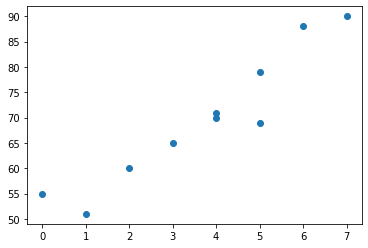

```python
import matplotlib.pyplot as plt

x=[2,0,3,5,4,7,4,6,5,1]
y=[60,55,65,69,70,90,71,88,79,51]

plt.scatter(x,y)
```

## 12.3 Linear Regression

[Watch demo video](https://youtu.be/QaK6CcVnElI)

We can use the variables x and y to **model** a linear relationship between x and y with a linear equation of the form $y=b+mx$.

The Least-Squares method can be used to obtain the predicted y values $\hat{y}$ as follows:

$\hat y=a+bx$

Where

$b=slope=r\times\frac{s_y}{s_x}$ and $a = \bar{y}-b\bar{x}$

Where $s_y$ and $s_x$ are std for x and y. The following code can be used to obtain the slope and intercept.

```
from scipy import stats
stats.linregress(x, y)
```

Example: The midterm exam out of a total of 100 points, x, and final exam out of a total of 200 points, y, scores for a random sample of 11 students is listed below. Find the slope and intercept of the regression line. Test if the correlation between x and y is significant at 0.05 level of significance.

| x | 65 | 67 | 71 | 71 | 66 | 75 | 67 | 70 | 71 | 69 | 69 |  |
| --- | --- | --- | --- | --- | --- | --- | --- | --- | --- | --- | --- | --- |
| **y** | **145** | **133** | **185** | **163** | **126** | **198** | **153** | **163** | **159** | **151** | **159** |  |

```python
x = [65, 67, 71, 71, 66, 75, 67, 70, 71, 69, 69]
y = [145, 133, 185, 163, 126, 198, 153, 163, 159, 151, 159]
from scipy import stats
stats.linregress(x, y)
```

```
LinregressResult(slope=6.364142538975501, intercept=-282.5556792873051, rvalue=0.8797451071731136, pvalue=0.00035593568153235875, stderr=1.1464698617902889)
```

Interpretation: slope=6.364142538975501, intercept=-282.5556792873051, rvalue=0.8797451071731136 (this is Pearson correlation coefficient), pvalue=0.00035593568153235875 (this p-value is for testing the significance of the correlation coefficient), stderr=1.1464698617902889

Since the p-value is less 0.05, there is significant correlation between x and y.

`slope=6.364142538975501, intercept=-282.5556792873051`.

Thus, $\hat{y}=-282.56+6.36x$ is the regression line with values rounded to two decimal places.

Example: he number of hours studied, x, and test scores, y, for 10 students are listed below. Find the the correlation coefficient (r-value), estimated slope and y-intercept of the regression line and the p-value for testing the significance of correlation.

| x | 2 | 0 | 3 | 5 | 4 | 7 | 4 | 6 | 5 | 1 |  |
| --- | --- | --- | --- | --- | --- | --- | --- | --- | --- | --- | --- |
| **y** | **60** | **55** | **65** | **69** | **70** | **90** | **71** | **88** | **79** | **51** |  |

```python
from scipy import stats

x=[2,0,3,5,4,7,4,6,5,1]
y=[60,55,65,69,70,90,71,88,79,51]

stats.linregress(x,y)
```

```
LinregressResult(slope=5.564625850340137, intercept=49.21088435374149, rvalue=0.9485857685252971, pvalue=2.8725087369610658e-05, stderr=0.6564713967897522)
```

Interpretation:

slope=5.564625850340137, intercept=49.21088435374149, r-value=0.9485857685252971, pvalue=2.8725087369610658e-05

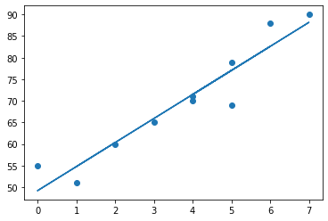

```python
import matplotlib.pyplot as plt
import numpy as np


x=[2,0,3,5,4,7,4,6,5,1]
y=[60,55,65,69,70,90,71,88,79,51]

x = np.array(x)
y = np.array(y)

y_hat = 5.564625850340137*x + 49.21088435374149

plt.scatter(x,y)
plt.plot(x,y_hat)
```

## Regression Line

The function `lin_reg(x,Y)` below provides the slope, y-intercept of the least-squares regression line. In addition it returns the R-square, p-value, t-test statistic for testing the significance of the correlation coefficient.

```python
def lin_reg(x,y):
    import statsmodels.api as sm
    import pandas as pd

    x_df = pd.DataFrame({'indpt':x})

    # to get intercept
    X = sm.add_constant(x_df)

    # fit the regression model
    model = sm.OLS(y, X)
    results = model.fit()
    print()
    if results.params[1]>0:
        r = results.rsquared**.5
    else: r = -1*results.rsquared**.5
    print('corr coeff r: ', r)
    print('R squared:', results.rsquared)
    print()
    print('estimated slope:', results.params[1])
    print('estimated y-intercept:', results.params[0])
    print()
    print('t test statistic:', results.tvalues[1])
    print('p-value:', results.f_pvalue)
    print()

    import matplotlib.pyplot as plt
    y_hat = results.predict(X)
    fig, ax = plt.subplots(figsize=(8,6))
    ax.plot(x, y, 'o', label="observed")
    ax.plot(x, y_hat, 'b-', label="reg line")
    ax.set_xlabel('indpt')
    ax.set_ylabel('dept')
    ax.legend(loc='best');
```

Example: The midterm exam, x, and final exam, y, scores for a random sample of 11 students is listed below. Find the slope and intercept of the regression line, correlation coefficient and draw a scatter plot.

| x | 65 | 67 | 71 | 71 | 66 | 75 | 67 | 70 | 71 | 69 | 69 |  |
| --- | --- | --- | --- | --- | --- | --- | --- | --- | --- | --- | --- | --- |
| **y** | **145** | **133** | **185** | **163** | **126** | **198** | **153** | **163** | **159** | **151** | **159** |  |

```python
x = [65, 67, 71, 71, 66, 75, 67, 70, 71, 69, 69]
y = [145, 133, 185, 163, 126, 198, 153, 163, 159, 151, 159]
```

```
corr coeff r:  0.8797451071731136
R squared: 0.7739514535950331

estimated slope: 6.364142538975502
estimated y-intercept: -282.5556792873052

t test statistic: 5.55107705058855
p-value: 0.0003559356815323585
```

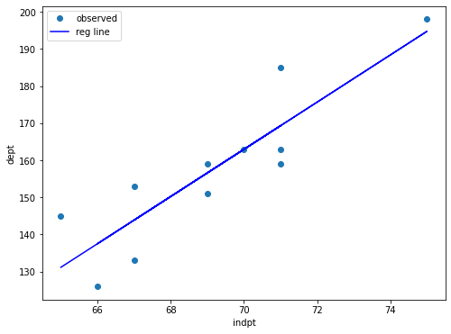

```python
lin_reg(x,y)
```

Interpretation: r=0.8797451071731136 indicates strong positive linear relationship. R squared: 0.7739514535950331 indicates 77.4% of the variation can be explained by the linear model. p-value: 0.0003559356815323585 indicates the correlation coefficient is significant.

## Predictions

Suppose you want to estimate, or predict, the final exam score of a student with midterm exam score of 70. The midterm exam scores (x-values) range from 65 to 75. Since 70 is inside this range, we can substitute x = 70 into the regression equation to find the predicted y value.

$\hat y= a+bx$

from the results (see above)

$\hat y=-282.5556792873052 + 6.364142538975502x$

$\hat y=-282.5556792873052 + 6.364142538975502\times 70$

```python
-282.5556792873052 + 6.364142538975502*70
```

```
162.9342984409799
```

A student with a midterm exam score of 70 is predicted to score 162.9 on the final exam.

# 13. Analysis of Categorical Data

Qualitative data can be classified consisting of counts or number of observations that fall into each category.

## 13.1 Goodness of Fit Test

[Watch demo video](https://youtu.be/2eF-IDmU3Hw)

Categorical or qualitative data can be organized by frequency distribution of a list of each category and the corresponding counts or relative frequencies.

A Chi-square goodness-of-fit is used to test whether a frequency distribution follows a given specific distribution.

$H_o:$ The random variable follows a certain given distribution or (the probability for each category, $P_i$, as given is *true*).

$H_a:$ The random variable does not follow the distribution in the null hypothesis

The Chi-square test statistic is given as:

$\chi^2=\sum_{i=1}^k{\frac{(O_i-E_i)^2}{E_i}}$

Where

$O_i$ is the observed value for category $i$

$E_i=nP_i$ is the expected value for category $i$ assuming $H_o$ is true.$n$ is sample size.

$\text{df}=k-1$

For large sample sizes $\chi^2$ is approximately follows the **chi-square probability distribution**

**Note**: In order to perfrom the Chi-Square goodness of fit, we assume:

- samples are randomly selected
- sample data consist of frequency counts for each category
- For each category, the expected frequency is at least 5

For chi-square goodness of fit test, use the following syntax with observed frequency stored in `obs` and expected frequency stored in `exp`:

```
from scipy import stats
stats.chisquare(obs,exp)
```

returns `Power_divergenceResult(statistic, pvalue)`

Example: A store manager claims that a plain M&M bag of candies contains an equal number of each of the six colors: brown, yellow, red, blue, orange, and green. The counts for each color of a randomly selected bag of plain M&M is given below. Test the store managers claim at 5% level of significance.

| color | frequency |
| --- | --- |
| brown | 57 |
| yellow | 64 |
| red | 54 |
| blue | 75 |
| orange | 86 |
| green | 64 |

The above table contains the observed ($O_i$) frequencies. We need to find the expected frequencies before we call the function. If the manager's claim is true there will be equal number of candies for each color. We need the total number of candies and divide it to 6 to get the expected frequencies.

```python
obs = [57,64,54,75,86,64]
```

```python
sum(obs)   #total number of candies in the bag
```

```
400
```

If the null is true, we expect an equal number in each category. That is, $P_i=\frac{1}{6}$ for all $i$. $E_i=nP_i=400/6$

| color | observed | expected |
| --- | --- | --- |
| brown | 57 | 400/6 |
| yellow | 64 | 400/6 |
| red | 54 | 400/6 |
| blue | 75 | 400/6 |
| orange | 86 | 400/6 |
| green | 64 | 400/6 |

```python
exp = [400/6,400/6,400/6,400/6,400/6,400/6]
```

```python
obs = [57,64,54,75,86,64]
```

```python
from scipy import stats

obs = [57,64,54,75,86,64]
exp = [400/6,400/6,400/6,400/6,400/6,400/6]

stats.chisquare(obs,exp)
```

```
Power_divergenceResult(statistic=10.67, pvalue=0.05833003695944934)
```

Interpretation: The Chi-square test statistic is equal to 10.67 . At the p-value is not less than 0.05 . We would fail to reject the null hypothesis.

Example: The number of sales of electric vehicles (EV) in the USA is given in the table below. Test a claim that the distribution of sales is uniform with $\alpha=0.05$.

| Brand | Sales |
| --- | --- |
| Ford | 2400000 |
| Toyota | 2200000 |
| Chevrolet | 2020000 |
| Honda | 1500000 |

```python
import numpy as np
from scipy import stats

obs = [2400000,2200000,2020000,1500000]  # observed frequency
sum = np.sum(obs)                        # sum of observed freq
exp = [sum/4,sum/4,sum/4,sum/4]          # expected freq

stats.chisquare(obs,exp)
```

```
Power_divergenceResult(statistic=220098.52216748768, pvalue=0.0)
```

Interpretation: The chi-square test statistics is 220098.52216748768 and the p-value 0.0. Reject the null hypothesis. There is enough evidence to conclude that the distribution is not uniform.

## 13.2 Test of Independence

[Watch demo video](https://youtu.be/buytZhGkBDs)

Sometimes, categorical data can be organized by a two-way classification or contingency table. Each cell (intersection of row and column) is the observed count.

$H_o:\text{The row and column variables are independent}$

$H_a:\text{The row and column variables are dependent}$

The Chi-square test statistic is given by:

$\chi^2=\sum_{i,j=1}^{rc}{\frac{(O_{ij}-E_{ij})^2}{E_{ij}}}$

where

$r$ and $c$ are the number of rows and columns respectively

$E_{ij}=\frac{r_ic_j}{n}$ where $r_i,c_j$ row i, column j totals.

$\text{df}=(r-1)(c-1)$

**Note**: In order to perfrom the Chi-Square test of independence, we assume:

- samples are randomly selected
- sample data consist of frequency counts for each two-way table
- For each cell, the expected frequency is at least 5

Use the function `chi2_test_of_indp` below with argument: each column from the observed frequency combined as `obs = [c1, c2, ...]`. Where `c1` is the list from column 1, `c2` is the list from column 2 ...

```python
def chi2_test_of_indp(obs):
    from scipy import stats
    chi2, p, dof, ex = stats.chi2_contingency(obs)

    print("chi-square test statitic:",chi2)
    print("p-value:", p)
```

Example: The contingency table below shows a random sample of white, black and Hispanic college students based on whether their family borrowed money to pay their college education. Test the hypothesis that borrowing money for college and race are independent at 1% level of significance. (adapted from Larson and Farber)

| race/borrow | Yes | No |
| --- | --- | --- |
| White | 49 | 64 |
| Black | 85 | 123 |
| Hispanic | 85 | 180 |

$H_0:$ Borrowing money for college and race are independent

$Ha:$ Borrowing money for college and race are dependent

```python
c1 = [49,85,85]
c2 = [64,123,180]

obs = [c1,c2]
```

```python
chi2_test_of_indp(obs)
```

```
chi-square test statitic: 5.993527985414218
p-value: 0.04994844064430499
```

Swapping the column and row still gives the same result (see below).

```python
c1 = [49,64]
c2 = [85,123]
c3 = [85,180]

obs = [c1,c2,c3]
chi2_test_of_indp(obs)
```

```
chi-square test statitic: 5.993527985414217
p-value: 0.04994844064430501
```

Example: The contingency table below shows the effects of Covid19 by race in the USA. Test the hypothesis that effects of Covid19 is independent of race at 5% level of significance.

Use the `chi2_test_of_indp` function below.

```python
def chi2_test_of_indp(obs):
    from scipy import stats
    chi2, p, dof, ex = stats.chi2_contingency(obs)

    print("chi-square test statistic:",chi2)
    print("p-value:", p)
```

```python
r1 = [100,170,70,110,190]
r2 = [100,340,100,280,280]
r3 = [100,240,100,200,230]

obs = [r1,r2,r3]

chi2_test_of_indp(obs)
```

```
chi-square test statistic: 36.38048143358525
p-value: 1.4955960363094355e-05
```

Interpretation: Since the p-value 1.4955960363094355e-05 is less than 5%, reject the null hypothesis. That is, there is enough evidence to reject the claim that the effects of Covid10 and race are independent.

# 14. Advanced Statistics Topics

## 14.1 Descriptive Statistics with Pandas

[Watch demo video](https://youtu.be/bnKcSrfjRKs)

### Pandas Library

#### Pandas DataFrame

The Pandas DataFrame function is used for entering the data values in a *spreadsheet* like format wtih rows and columns labeled 0, 1, 2,... by default. Pandas output is typically displayed as DataFrame too.

**Note**: We will use the variable name `x` to store dataset in *Python List*.We will use the variable name `x_df` to store dataset in *Pandas DataFrame*.

To convert the Python list `x` to pandas dataframe `x_df` and display the results:

1. Click `+ Code`
2. Type `import pandas as pd`
3. Type `x = [x1, x2, ...]`
4. Type `x_df = pd.DataFrame({'column_name':x})`
5. Type `x_df`
6. Click `play` button

**Warning**: Like all Python variables `x_df` will only contain dataset that was stored last. Old values are replaced(updated) by the last data values stored.

Example: The dataset below is the waiting time, in minutes, of customers at a fast food restaurant. Write a pandas program to store and display the dataset in DataFrame.

```
5, 3, 4, 1, 5, 3, 5, 2, 3, 2, 5, 4, 4, 6, 4, 3, 4, 1, 2,
                  5
```

1. Click `+ Code`
2. Type `import pandas as pd`
3. Type

   ```
   x = [5, 3, 4, 1, 5, 3, 5, 2, 3, 2, 5, 4, 4, 6, 4, 3, 4, 1,
                       2, 5]
   ```

4. Type `x_df = pd.DataFrame({'waiting_time':x})`
5. Type `print(x_df)`
6. Click `play` button

```python
import pandas as pd
x = [5, 3, 4, 1, 5, 3, 5, 2, 3, 2, 5, 4, 4, 6, 4, 3, 4, 1, 2, 5]
x_df = pd.DataFrame({'waiting_time':x})
print(x_df)
```

```
    waiting_time
0              5
1              3
2              4
3              1
4              5
5              3
6              5
7              2
8              3
9              2
10             5
11             4
12             4
13             6
14             4
15             3
16             4
17             1
18             2
19             5
```

**Note**: Unlike Numpy, Pandas DataFrame output is given in a spreadsheet like format. It has both column(s) and row(s). The first column is called the `index` column and it is automatically generated by Python. In the output above, the first column `0, 1, 2, ..., 19` is the `index` column. **Make a special note that it does NOT start at 1. It starts at 0**. `Waiting_time` is the name of the second column after the `index` column. We only have one column with dataset here: `waiting_time`. The variable name for the whole DataFrame, including the columns and rows, is `x_df`.

**Numpy vs. Pandas**

Both numpy and pandas can be used for most computations in descriptive statistics. Unlike numpy, Pandas requires converting the dataset list to Pandas dataframe before any computation or analysis. But Pandas has more statistical computing and plotting capabilities.

### Value Counts and Relative Frequency using Pandas

1. Pandas syntax for frequency

```
import pandas as pd  # pd alias for pandas
x=[x1,x2,x3,...]
x_df=pd.DataFrame({'column_name':x})
x_df.value_counts()
```

The above returns counts of unique values (frequencies).

2. Pandas syntax for a relative frequency

```
import pandas as pd
x=[x1,x2,x3,...]
x_df=pd.DataFrame({'column_name':x})
x_df.value_counts(normalize=True)
```

The above returns a relative frequency of the unique values (Frequency Ã· Total Frequency)

Example: The dataset below is the waiting time, in minutes, of customers at a fast food restaurant. Write a pandas program to construct a frequency distribution.

```
5, 3, 4, 1, 5, 3, 5, 2, 3, 2, 5, 4, 4, 6, 4, 3, 4, 1, 2,
                  5
```

1. Click `+ Code`
2. Type `import pandas as pd`
3. Type

   ```
   x= [5, 3, 4, 1, 5, 3, 5, 2, 3, 2, 5, 4, 4, 6, 4, 3, 4, 1,
                       2, 5]
   ```

4. Type `x_df = pd.DataFrame(x,columns = ['waiting_time'])`
5. Type `x_df.value_counts(sort=False)`
6. Click `play` button

```python
import pandas as pd
x= [5, 3, 4, 1, 5, 3, 5, 2, 3, 2, 5, 4, 4, 6, 4, 3, 4, 1, 2, 5]
x_df = pd.DataFrame(x,columns = ['waiting_time'])
x_df.value_counts(sort=False)    # if sort is True it will sort by frequency
```

```
waiting_time
1               2
2               3
3               4
4               5
5               5
6               1
dtype: int64
```

Interpretation from the above output:

| waiting time | frequency |
| --- | --- |
| 1 | 2 |
| 2 | 3 |
| 3 | 4 |
| 4 | 5 |
| 5 | 5 |
| 6 | 1 |

Example: The dataset below is the waiting time, in minutes, of customers at a fast food restaurant. Write a pandas program to construct a relative frequency distribution.

```
5, 3, 4, 1, 5, 3, 5, 2, 3, 2, 5, 4, 4, 6, 4, 3, 4, 1, 2,
                  5
```

```python
import pandas as pd

x = [5, 3, 4, 1, 5, 3, 5, 2, 3, 2, 5, 4, 4, 6, 4, 3, 4, 1, 2, 5]
x_df = pd.DataFrame({'waiting_time':x})
x_df.value_counts(normalize=True, sort=False)    # add normalize=True for relative freq
```

```
waiting_time
1               0.10
2               0.15
3               0.20
4               0.25
5               0.25
6               0.05
dtype: float64
```

Interpretation from the above output

| waiting time | rel-freq |
| --- | --- |
| 1 | 0.10 |
| 2 | 0.15 |
| 3 | 0.20 |
| 4 | 0.25 |
| 5 | 0.25 |
| 6 | 0.05 |

Example: 20 students were asked if they were registered to vote. Their responses are given below. Write a program to construct a frequency and relative frequency distribution using pandas library.

```
NO, NO, YES, YES, NO, YES, NO, NO, YES, NO, YES, NO, NO, YES,
                  YES, YES, YES, NO, YES, YES
```

```python
# non-numerical values should be in 'quotes'
x = ['NO', 'NO', 'YES', 'YES', 'NO', 'YES', 'NO', 'NO', 'YES', 'NO',
             'YES', 'NO', 'NO', 'YES', 'YES', 'YES', 'YES', 'NO', 'YES', 'YES']
x_df = pd.DataFrame({'vote':x})
x_df.value_counts()
```

```
vote
YES     11
NO       9
dtype: int64
```

Interpretation from the above output

vote

| Yes | NO |
| --- | --- |
| 11 | 9 |

```python
# non-numerical values should be in 'quotes'
x = ['NO', 'NO', 'YES', 'YES', 'NO', 'YES', 'NO', 'NO', 'YES', 'NO',
             'YES', 'NO', 'NO', 'YES', 'YES', 'YES', 'YES', 'NO', 'YES', 'YES']
x_df = pd.DataFrame({'vote':x})
x_df.value_counts(normalize=True)
```

```
vote
YES     0.55
NO      0.45
dtype: float64
```

Interpretation from the above output

| Yes | No |
| --- | --- |
| 0.55 | 0.45 |

### Descriptive Statistics with Pandas

Pandas syntax for the mean:

```
import pandas as pd
x = [x1,x2,x3,...,xn]
x_df = pd.DataFrame({'column_name':x})
x_df.mean()
```

Example: Find the mean of the data set `1,2,3` using pandas.

```python
import pandas as pd
x = [1,2,3]
x_df = pd.DataFrame({'x':x})
x_df.mean()
```

```
x    2.0
dtype: float64
```

Interpretation: the mean is 2.0

Pandas syntax for the median:

```
import pandas as pd
x = [x1,x2,x3,...,xn]
x_df = pd.DataFrame(x)
x_df.median()
```

Example: find the median of the data set `1,2,3,4`

```python
import pandas as pd
x = [1,2,3,4]
x_df = pd.DataFrame({'x':x})
x_df.median()
```

```
x    2.5
dtype: float64
```

Interpretation: the median is 2.5

### Mode

The mode(s) of a data set is the most frequent value(s).

pandas syntax for mode

```
import pandas as pd
x = [x1,x2,x3,...]
x_df = pd.DataFrame(x)
x_df.mode()
```

Example: find the mode of the data set `1,2,3,3,4,4`

```python
import pandas as pd
x = [1,2,3,3,4,4]
x_df = pd.DataFrame({'x':x})
x_df.mode()
```

|  | x |
| --- | --- |
| 0 | 3 |
| 1 | 4 |

Interpretation: There are two modes here, 3 and 4. It is bimodal. Recall that the columns and rows in pandas are 0, 1, 2,3,...

In this case, there is one column x and two rows 0 and 1.

```
81, 21, 53, 32, 80, 13, 26, 42, 35, 41, 14, 25, 87, 62, 46,
                  40, 32, 52, 85, 28, 17, 36, 83, 79, 18, 50, 17, 36, 36,
                  19
```

```python
import pandas as pd
x = [81, 21, 53, 32, 80, 13, 26, 42, 35, 41, 14, 25, 87, 62, 46, 40,
             32, 52, 85, 28, 17, 36, 83, 79, 18, 50, 17, 36, 36, 19]
x_df = pd.DataFrame({'score':x})

print("The mean",x_df.mean())
print('the median',x_df.median())
print('the mode',x_df.mode())
```

```
The mean score    42.866667
dtype: float64
the median score    36.0
dtype: float64
the mode    score
0     36
```

Interpretation: The mean is 42.866667, the median is 36.0 and the mode is 36

```
17, 81, 21, 53, 32, 80, 13, 26, 42, 35, 41, 14, 25, 87, 62,
                  46, 40, 32, 52, 85, 28, 17, 36, 83, 79, 18, 50, 17, 36, 36,
                  19
```

```python
import pandas as pd
x = [17, 81, 21, 53, 32, 80, 13, 26, 42, 35, 41, 14, 25, 87, 62, 46, 40,
             32, 52, 85, 28, 17, 36, 83, 79, 18, 50, 17, 36, 36, 19]
x_df = pd.DataFrame({'score':x})

print("Mode",x_df.mode())
```

```
Mode    score
0     17
1     36
```

There are two modes here: 17 and 36.

pandas syntax for variance and std:

```
import pandas as pd
x = [x1,x2,x3,...]
x_df = pd.DataFrame({'column_name':x})
x_df.var(ddof=0)      #pop variance
x_df.var()            #sample variance
x_df.std(ddpf=0)      #pop std
x_df.std()            #sample std
```

**Note**: `ddof=1` by default for pandas

Example: find the population variance of the data set `1,2,3,4,5`

1. Click `+ Code`
2. Type `import pandas as pd`
3. Type `x = [1,2,3,4,5]`
4. Type `x_df =pd.DataFrame(x)`
5. Type `x_df.var(ddof=0)`
6. Click `play`

```python
import pandas as pd
x = [1,2,3,4,5]
x_df =pd.DataFrame(x)
x_df.var(ddof=0)              #in Pandas ddof=1 by default
```

```
0    2.0
dtype: float64
```

Interpretation: the population variance is 2.0

Example: find the sample variance of the data set `1,2,3,4,5`

```python
import pandas as pd
x = [1,2,3,4,5]
x_df =pd.DataFrame(x)
x_df.var()
```

```
0    2.5
dtype: float64
```

Interpretation: the sample variance is 2.5

Example: find the population standard deviation of the data set `1,2,3,4,5`

```python
import pandas as pd
x = [1,2,3,4,5]
x_df =pd.DataFrame(x)
x_df.std(ddof=0)
```

```
0    1.414214
dtype: float64
```

Interpretation: the population standard deviation is 1.414214

Example: find the sample standard deviation of the data set `1,2,3,4,5`

```python
import pandas as pd
x = [1,2,3,4,5]
x_df =pd.DataFrame(x)
x_df.std()
```

```
0    1.581139
dtype: float64
```

Interpretation: the sample standard deviation is 1.581139

```
81, 21, 53, 32, 80, 13, 26, 42, 35, 41, 14, 25, 87, 62, 46,
                  40, 32, 52, 85, 28, 17, 36, 83, 79, 18, 50, 17, 36, 36,
                  19
```

```python
import pandas as pd

x = [81, 21, 53, 32, 80, 13, 26, 42, 35, 41, 14, 25, 87, 62, 46, 40, 32,
             52, 85, 28, 17, 36, 83, 79, 18, 50, 17, 36, 36, 19]

x_df = pd.DataFrame({'score':x})

x_df.std()        #sample standard deviation
```

```
score    23.555852
dtype: float64
```

In the above output, `23.555852` is the sample standard deviation.

```python
import pandas as pd

x = [81, 21, 53, 32, 80, 13, 26, 42, 35, 41, 14, 25, 87, 62, 46, 40, 32,
             52, 85, 28, 17, 36, 83, 79, 18, 50, 17, 36, 36, 19]

x_df = pd.DataFrame({'score':x})

x_df.var()        #sample variance
```

```
score    554.878161
dtype: float64
```

Interpretation: the sample variance is 554.878161

```
81, 21, 53, 32, 80, 13, 26, 42, 35, 41, 14, 25, 87, 62, 46,
                  40, 32, 52, 85, 28, 17, 36, 83, 79, 18, 50, 17, 36, 36,
                  19
```

```python
import pandas as pd

x = [81, 21, 53, 32, 80, 13, 26, 42, 35, 41, 14, 25, 87, 62, 46, 40, 32,
             52, 85, 28, 17, 36, 83, 79, 18, 50, 17, 36, 36, 19]

x_df = pd.DataFrame({'score':x})

x_df.std(ddof=0)     # population standard deviation ddof degrees of freedom
```

```
score    23.159927
dtype: float64
```

In the above output, `23.159927` is the population standard deviation.

```python
import pandas as pd

x = [81, 21, 53, 32, 80, 13, 26, 42, 35, 41, 14, 25, 87, 62, 46, 40, 32,
             52, 85, 28, 17, 36, 83, 79, 18, 50, 17, 36, 36, 19]

x_df = pd.DataFrame({'score':x})

x_df.var(ddof=0)     # population variance
```

```
score    536.382222
dtype: float64
```

Interpretation: The population variance is 536.382222

### Percentiles

pandas syntax for percentile

```
import pandas as pd
x_df.quantile(p)
```

```
81, 21, 53, 32, 80, 13, 26, 42, 35, 41, 14, 25, 87, 62, 46,
                  40, 32, 52, 85, 28, 17, 36, 83, 79, 18, 50, 17, 36, 36,
                  19
```

- Find the 70th percentile.

**Note**: These results by pandas could be different from other results that use a different method of computing percentiles.

```python
import pandas as pd
x=[81, 21, 53, 32, 80, 13, 26, 42, 35, 41, 14, 25, 87, 62, 46, 40, 32,
           52, 85, 28, 17, 36, 83, 79, 18, 50, 17, 36, 36, 19]
x_df = pd.DataFrame({'score':x})
x_df.quantile(.70)
```

```
score    50.6
Name: 0.7, dtype: float64
```

Interpretation: The 70th percentile is approximately 50.6

**Note**: In the output above, `score` is the name of the variable/column, `50.6` is the calculated 70th percentile, and `dytype: float64` tells us that this result `50.6` is of type `float64` is a double precision float.

```
81, 21, 53, 32, 80, 13, 26, 42, 35, 41, 14, 25, 87, 62, 46,
                  40, 32, 52, 85, 28, 17, 36, 83, 79, 18, 50, 17, 36, 36,
                  19
```

- Find the 83rd percentile.

**Note**: These results by pandas could be different from other results that use a different method of computing percentiles.

```python
import pandas as pd
x=[81, 21, 53, 32, 80, 13, 26, 42, 35, 41, 14, 25, 87, 62, 46, 40, 32,
           52, 85, 28, 17, 36, 83, 79, 18, 50, 17, 36, 36, 19]
x_df = pd.DataFrame({'score':x})
x_df.quantile(.83)
```

```
score    79.07
Name: 0.83, dtype: float64
```

Interpretation: The 83rd percentile is 79.07

```
81, 21, 53, 32, 80, 13, 26, 42, 35, 41, 14, 25, 87, 62, 46,
                  40, 32, 52, 85, 28, 17, 36, 83, 79, 18, 50, 17, 36, 36,
                  19
```

1. Find the 70th percentile.
2. Find the 83rd percentile.
3. Find the 1st quartile.
4. Find the 3rd quartile.

**Note**: These results by pandas could be different from other results that use a different method of computing percentiles.

```python
import pandas as pd
x=[81, 21, 53, 32, 80, 13, 26, 42, 35, 41, 14, 25, 87, 62, 46, 40, 32,
           52, 85, 28, 17, 36, 83, 79, 18, 50, 17, 36, 36, 19]
x_df = pd.DataFrame({'score':x})
x_df.quantile([.7,.83,.25,.75])  # this will print all of them at once
```

|  | score |
| --- | --- |
| 0.70 | 50.60 |
| 0.83 | 79.07 |
| 0.25 | 25.25 |
| 0.75 | 52.75 |

Interpretation: In the output above, the first column is the percentiles given in decimals and the second column is the corresponding values. For example, **0.70** 50.60 tells us the `70th` percentile is `50.60`.

| Percentile | score |
| --- | --- |
| 70th | 50.60 |
| 83rd | 79.07 |
| 25th | 25.25 |
| 75th | 52.75 |

### Summary Statistics, Skewness and Kurtosis

use `x_df.describe()` to get summary stats of a data. This code returns: size(count), mean, std, min, 1st, 2nd, 3rd quartile, max.

use `x_df.skew()` for skewness and `x_df.kurtosis()` for kurtosis.

Skewness is a measure of symmetry/asymmetry of the shape and kurtosis is a measure of heavy/light tail.

```
81, 21, 53, 32, 80, 13, 26, 42, 35, 41, 14, 25, 87, 62, 46,
                  40, 32, 52, 85, 28, 17, 36, 83, 79, 18, 50, 17, 36, 36,
                  19
```

```python
import pandas as pd
x=[81, 21, 53, 32, 80, 13, 26, 42, 35, 41, 14, 25, 87, 62, 46, 40, 32,
           52, 85, 28, 17, 36, 83, 79, 18, 50, 17, 36, 36, 19]
x_df = pd.DataFrame({'data':x})

x_df.describe()
```

|  | data |
| --- | --- |
| count | 30.000000 |
| mean | 42.866667 |
| std | 23.555852 |
| min | 13.000000 |
| 25% | 25.250000 |
| 50% | 36.000000 |
| 75% | 52.750000 |
| max | 87.000000 |

In the above output, count is the number of data values, std is sample standard deviation, 25% is the 1st quartile or 25th percentile.

| interpretation | pandas | value |
| --- | --- | --- |
| n | count | 30.000000 |
| mean | mean | 42.866667 |
| standard deviation | std | 23.555852 |
| minimum | min | 13.000000 |
| 25th percentile | 25% | 25.250000 |
| 50th percentile | 50% | 36.000000 |
| 75th percentile | 75% | 52.750000 |
| maximum | max | 87.000000 |

```python
x_df.skew()
```

```
data    0.694929
dtype: float64
```

Interpretation: The skewness index is 0.694929. If the value of skew is positive, the shape of the data is skewed to the right. Negative implies skewed to the left and zero indicates no skewness.

```python
x_df.kurtosis()
```

```
data   -0.71888
dtype: float64
```

Interpretation: The kurtosis index is -0.71888. For kurtosis, the general guideline is that if the value is greater than 3, the distribution has heavier tails and if it is less than 3, it indicates a distribution that has lighter tails as compared to the normal distribution.

## 14.2 Uploading Dataset

### Uploading Excel or csv Files from Your Computer

[Watch demo video](https://youtu.be/XBCQUUF3enY)

If your data file is in Excel spreadsheet or csv (comma separated value) format stored in your local computer, you can run the code-cell below to upload the file in to **Google Colab**.

```
from google.colab import files
uploaded = files.upload()
```

After running the code, click the `Choose Files` button and browse your computer's folder to locate your Excel or csv file. Open the file. Colab will upload it with the same file name, for example `file_name.xlsx`. Next, you will need to run the code-cell below to convert it to pandas dataframe.

```
import io
import pandas as pd

excel_file = io.BytesIO(uploaded['file_name.xlsx'])
x_df = pd.read_excel(excel_file)
```

Make sure the file names match. Now your dataframe, `x_df`, is ready for analysis and plotting.

For a csv file run the code-cell below

```
import io
import pandas as pd

csv_file = io.StringIO(uploaded['MyData.csv'].decode('utf-8'))
x_df = pd.read_csv(csv_file)
```

### Uploading csv Dataset From URL

[Watch demo video](https://youtu.be/32i9LhP1Tno)

If you want to upload a csv file from the internet with url address, use the code below. Replace the web_link_address with your url address first.

```
import pandas as pd
url = `www_link_address`

x_df = pd.read_csv(url)
```

Example: Write a program to read the dataset (URL below) and display the shape (size) of the dataset. In addition, display the first and last five rows of the dataset.

https://raw.githubusercontent.com/simeonaman/demo/master/my_csv_file.csv

```python
import pandas as pd

url = 'https://raw.githubusercontent.com/simeonaman/demo/master/my_csv_file.csv'

x_df = pd.read_csv(url)
```

```python
x_df.shape   # displays the number of rows and columns
```

```
(180, 8)
```

Interpretation: There are 18o rows and 8 columns in `x_df`.

```python
x_df   # displays the frist 5 and the last 5 rows
```

|  | id | gender | section | time | level | test1_score | test2_score | test3_score |
| --- | --- | --- | --- | --- | --- | --- | --- | --- |
| 0 | 1 | female | C | 17.3 | low | 65.4 | 84.3 | 51.9 |
| 1 | 2 | female | D | 5.1 | low | 72.4 | 86.1 | 52.0 |
| 2 | 3 | female | A | 2.4 | low | 73.8 | 84.2 | 53.1 |
| 3 | 4 | female | A | 8.8 | low | 70.2 | 87.9 | 52.0 |
| 4 | 5 | male | B | 15.0 | low | 60.3 | 81.4 | 55.5 |
| ... | ... | ... | ... | ... | ... | ... | ... | ... |
| 175 | 176 | male | B | 13.2 | high | 78.8 | 89.3 | 52.5 |
| 176 | 177 | female | B | 12.6 | high | 76.5 | 83.4 | 50.0 |
| 177 | 178 | male | D | 8.4 | high | 78.1 | 86.3 | 51.0 |
| 178 | 179 | male | C | 9.5 | high | 76.6 | 86.6 | 52.4 |
| 179 | 180 | male | C | 16.2 | high | 83.1 | 89.4 | 54.1 |

180 rows Ã— 8 columns

### Cleaning Data

Common cleaning data techniques include removing duplicate columns or observations (rows), combining or summarizing columns and replacing or deleting missing values.

1. To drop a column use

`x_df.drop(['column_name'],axis=1,inplace=True)`

2. To drop duplcate rows by keeping only the first observation, use

```
x_df.drop_duplicates(subset='column_name',
                  keep="first",inplace=True)
```

3. To combine columns and make a new one, for example `average` use

`df['average']=(x_df['test1']+x_df['test2]+x_df['test3])/3`

4. To drop the rows where at least one element is missing, use

`x_df.dropna()`

5. To drop the columns where at least one element is missing, use

`x_df.dropna(axis='columns')`

6. `x_df.isnull().sum()` returns the number of missing values for each column
7. To replace missing (NaN) values with the mean, use

```
x_df['column_name'].fillna(value=df['column_name'].mean(),
                  inplace=True)
```

### Downloading Data as csv file to your computer

If you make changes to your `x_df` in Google colab and want to save or download your updated `x_df` to your local computer you can follow the steps below. For more on updating your dataframe, see the Cleaning Data section above.

first run the code-cell below

`from google.colab import drive`

then on a new code-cell run

`drive.mount('/drive')`

You will receive a message that says go to the url link to get authorization from your Google account. Click the link, then choose your Google Account (if you have more than one), then scroll down and click `allow`. Next you will need to copy the authorization code. Then go back to your Colab, paste the code where it says `Enter Authorization Code` and press enter.

You will see a new message: `Mounted at /drive`

Now you will need to choose a folder in your Google Drive where the file is to be downloaded or saved. For example:

`x_df.to_csv('/drive/My Drive/Yiakl/my_csv_file.csv')`

your dataframe name is `x_df` and your file will be downloaded to your Google Drive under the `Yiakl` folder. The name of the downloaded file is chosen here to be `my_csv_file.csv`.

## 14.3 Descriptive Statistics (multiple columns)

[Demo Vidoe Link](https://youtu.be/x0K71-770_o)

### Sample Dataset

We will use the students test scores dataset found at https://raw.githubusercontent.com/simeonaman/demo/master/my_csv_file.csv. See below on how to upload it. This is "clean" dataset.

1. This is simulated data (not real)
2. 180 rows (observations) and 8 columns (variables)
3. `time` is completion time for `test1_score`
4. `id, gender, section and level` are categorical data
5. `time, test1_score, test2_score, and test3_score` are quantitative data

### Basic Info about the Dataset

`x_df.info()` gives basic information about the dataset stored in x_df: column names, non-empty data values, and data types.

Example: Write a program to display basic information about the dataset (URL below).

https://raw.githubusercontent.com/simeonaman/demo/master/my_csv_file.csv

```python
import pandas as pd

url = 'https://raw.githubusercontent.com/simeonaman/demo/master/my_csv_file.csv'

x_df = pd.read_csv(url)
```

```python
x_df.info()
```

```
<class 'pandas.core.frame.DataFrame'>
RangeIndex: 180 entries, 0 to 179
Data columns (total 8 columns):
 #   Column       Non-Null Count  Dtype
---  ------       --------------  -----
 0   id           180 non-null    int64
 1   gender       180 non-null    object
 2   section      179 non-null    object
 3   time         180 non-null    float64
 4   level        180 non-null    object
 5   test1_score  180 non-null    float64
 6   test2_score  180 non-null    float64
 7   test3_score  180 non-null    float64
dtypes: float64(4), int64(1), object(3)
memory usage: 11.4+ KB
```

Interpretation:

1. The first row tells us the object `x_df` is of `class` DataFrame from pandas
2. The second, `RangeIndex`, tells us there are 180 entries 0 to 179

### Descriptive Stats: mean, std, quartiles, frequencies, correlations etc

Example: Write a program to read the dataset (URL below) and display the descriptive statistics - count, mean, std, 1st quartile, 2nd quartile, 3rd quartile and max of 'test1_score`.

https://raw.githubusercontent.com/simeonaman/demo/master/my_csv_file.csv

```python
import pandas as pd

url='https://raw.githubusercontent.com/simeonaman/demo/master/my_csv_file.csv'

x_df = pd.read_csv(url)
```

```python
x_df['test1_score'].describe()
```

```
count    180.000000
mean      74.410000
std        5.890378
min       58.800000
25%       70.700000
50%       74.150000
75%       78.625000
max       90.300000
Name: test1_score, dtype: float64
```

Example: Write a program to read the dataset (URL below) and display the descriptive statistics - count, mean, std, 1st quartile, 2nd quartile, 3rd quartile and max of `test1_score` and `test2_score`.

https://raw.githubusercontent.com/simeonaman/demo/master/my_csv_file.csv

```python
import pandas as pd

url='https://raw.githubusercontent.com/simeonaman/demo/master/my_csv_file.csv'

x_df = pd.read_csv(url)
```

```python
x_df[['test1_score','test2_score']].describe()
```

|  | test1_score | test2_score |
| --- | --- | --- |
| count | 180.000000 | 180.000000 |
| mean | 74.410000 | 86.150000 |
| std | 5.890378 | 2.545332 |
| min | 58.800000 | 78.500000 |
| 25% | 70.700000 | 84.450000 |
| 50% | 74.150000 | 86.650000 |
| 75% | 78.625000 | 88.000000 |
| max | 90.300000 | 90.700000 |

### Descriptive Statistics: All quantitative variables

Example: Write a program to read the dataset (URL below) and display the descriptive statistics - count, mean, std, 1st quartile, 2nd quartile, 3rd quartile and max of all variables(columns).

https://raw.githubusercontent.com/simeonaman/demo/master/my_csv_file.csv

```python
import pandas as pd

url='https://raw.githubusercontent.com/simeonaman/demo/master/my_csv_file.csv'

x_df = pd.read_csv(url)
```

```python
x_df.describe()   # summary for all quantitative columns
```

|  | id | time | test1_score | test2_score | test3_score |
| --- | --- | --- | --- | --- | --- |
| count | 180.000000 | 180.000000 | 180.000000 | 180.000000 | 180.000000 |
| mean | 90.500000 | 10.321111 | 74.410000 | 86.150000 | 53.785000 |
| std | 52.105662 | 4.725398 | 5.890378 | 2.545332 | 2.693101 |
| min | 1.000000 | -4.500000 | 58.800000 | 78.500000 | 49.900000 |
| 25% | 45.750000 | 7.075000 | 70.700000 | 84.450000 | 51.700000 |
| 50% | 90.500000 | 9.950000 | 74.150000 | 86.650000 | 53.200000 |
| 75% | 135.250000 | 13.500000 | 78.625000 | 88.000000 | 55.350000 |
| max | 180.000000 | 22.500000 | 90.300000 | 90.700000 | 64.300000 |

The summary for the variable `id` is meaningless and should be ignored.

### Grouped Frequencies

Example: Write a program to read the dataset (URL below) and display the frequency distribution by 'gender`. Change the frequencies to percent.

https://raw.githubusercontent.com/simeonaman/demo/master/my_csv_file.csv

```python
import pandas as pd

url='https://raw.githubusercontent.com/simeonaman/demo/master/my_csv_file.csv'

x_df = pd.read_csv(url)
```

```python
x_df.value_counts(subset=['gender'])  # value counts by the variable(column) gender
```

```
gender
male      98
female    82
dtype: int64
```

```python
x_df.value_counts(subset=['gender'],normalize=True).mul(100).round(1).astype(str)+'%'
```

```
gender
male      54.4%
female    45.6%
dtype: object
```

### Summary Statistics Grouped by Gender

Example: Write a program to read the dataset (URL below) and display a table of `test1_score` mean, min, max, std, size grouped by `gender`.

https://raw.githubusercontent.com/simeonaman/demo/master/my_csv_file.csv

```python
import pandas as pd

url='https://raw.githubusercontent.com/simeonaman/demo/master/my_csv_file.csv'

x_df = pd.read_csv(url)
```

```python
x_df.groupby(['gender']).agg({'test1_score': ['mean', 'min', 'max','std','size']})
```

| gender | test1_score mean | test1_score min | test1_score max | test1_score std | test1_score size |
| --- | --- | --- | --- | --- | --- |
| female | 74.013415 | 58.8 | 87.6 | 6.234309 | 82 |
| male | 74.741837 | 60.3 | 90.3 | 5.597126 | 98 |

Example: Write a program to read the dataset (URL below) and display a table of `test1_score` mean, min, max, std, size grouped by `level`.

https://raw.githubusercontent.com/simeonaman/demo/master/my_csv_file.csv

```python
import pandas as pd

url='https://raw.githubusercontent.com/simeonaman/demo/master/my_csv_file.csv'

x_df = pd.read_csv(url)
```

```python
x_df.groupby(['level']).agg({'test1_score': ['mean', 'min', 'max','std','size']})
```

| level | test1_score mean | test1_score min | test1_score max | test1_score std | test1_score size |
| --- | --- | --- | --- | --- | --- |
| high | 79.613333 | 70.9 | 90.3 | 3.617306 | 60 |
| low | 68.775000 | 58.8 | 76.1 | 4.350282 | 60 |
| medium | 74.841667 | 66.6 | 85.7 | 3.638881 | 60 |

https://raw.githubusercontent.com/simeonaman/demo/master/my_csv_file.csv

```python
x_df.groupby(['section']).agg({'test1_score': ['mean', 'min', 'max','std','size']})
```

| section | test1_score mean | test1_score min | test1_score max | test1_score std | test1_score size |
| --- | --- | --- | --- | --- | --- |
| A | 73.869565 | 58.8 | 87.6 | 6.367552 | 46 |
| B | 73.695833 | 60.3 | 90.3 | 6.155398 | 48 |
| C | 73.443243 | 61.7 | 84.2 | 6.343568 | 37 |
| D | 76.241667 | 66.4 | 85.7 | 4.312961 | 48 |

### Grouped by Two Categorical Variables

Example: Write a program to read the dataset (URL below) and display a table of `test1_score` mean, min, max, std, size grouped by `level` and `gender`.

https://raw.githubusercontent.com/simeonaman/demo/master/my_csv_file.csv

```python
import pandas as pd

url='https://raw.githubusercontent.com/simeonaman/demo/master/my_csv_file.csv'

x_df = pd.read_csv(url)
```

```python
x_df.groupby(['level','gender']).agg({'test1_score': ['mean', 'min', 'max','std','size']})
```

| level | gender | test1_score mean | test1_score min | test1_score max | test1_score std | test1_score size |
| --- | --- | --- | --- | --- | --- | --- |
| high | female | 79.684000 | 70.9 | 87.6 | 3.637728 | 25 |
|  | male | 79.562857 | 71.6 | 90.3 | 3.654979 | 35 |
| low | female | 68.469697 | 58.8 | 76.1 | 4.876377 | 33 |
|  | male | 69.148148 | 60.3 | 76.1 | 3.662741 | 27 |
| medium | female | 75.729167 | 71.4 | 81.4 | 2.804884 | 24 |
|  | male | 74.250000 | 66.6 | 85.7 | 4.031271 | 36 |

### Grouped by Three Categorical Variables

Example: Write a program to read the dataset (URL below) and display a table of `test1_score` mean, min, max, std, size grouped by `level`, `gender` and `section`.

https://raw.githubusercontent.com/simeonaman/demo/master/my_csv_file.csv

```python
import pandas as pd

url='https://raw.githubusercontent.com/simeonaman/demo/master/my_csv_file.csv'

x_df = pd.read_csv(url)
```

```python
x_df.groupby(['level','section','gender']).agg({'test1_score': ['mean', 'min', 'max','std','size']})
```

| level | section | gender | test1_score mean | test1_score min | test1_score max | test1_score std | test1_score size |
| --- | --- | --- | --- | --- | --- | --- | --- |
| high | A | female | 80.857143 | 75.7 | 87.6 | 4.595236 | 7 |
|  |  | male | 78.571429 | 72.9 | 86.1 | 4.312661 | 7 |
|  | B | female | 78.266667 | 74.0 | 81.6 | 2.838074 | 6 |
|  |  | male | 80.171429 | 73.6 | 90.3 | 5.362125 | 7 |
|  | C | female | 79.350000 | 70.9 | 84.2 | 4.749210 | 6 |
|  |  | male | 79.477778 | 71.6 | 83.1 | 3.622422 | 9 |
|  | D | female | 80.066667 | 78.0 | 82.3 | 1.709581 | 6 |
|  |  | male | 79.709091 | 75.2 | 84.2 | 2.279673 | 11 |
| low | A | female | 67.788889 | 58.8 | 74.1 | 5.528889 | 9 |
|  |  | male | 66.683333 | 62.1 | 69.4 | 3.491370 | 6 |
|  | B | female | 66.233333 | 60.5 | 72.1 | 4.596375 | 6 |
|  |  | male | 68.950000 | 60.3 | 74.9 | 4.021401 | 10 |
|  | C | female | 66.900000 | 61.7 | 74.0 | 4.232021 | 9 |
|  |  | male | 69.400000 | 65.6 | 71.2 | 1.925271 | 7 |
|  | D | female | 72.211111 | 66.4 | 76.1 | 3.262072 | 9 |
|  |  | male | 72.900000 | 69.9 | 76.1 | 2.970971 | 4 |
| medium | A | female | 76.360000 | 71.8 | 81.3 | 3.856553 | 5 |
|  |  | male | 74.166667 | 70.8 | 78.0 | 2.133002 | 12 |
|  | B | female | 76.022222 | 72.6 | 81.4 | 3.175601 | 9 |
|  |  | male | 73.550000 | 66.6 | 81.8 | 4.818541 | 10 |
|  | C | female | 75.650000 | 75.6 | 75.7 | 0.070711 | 2 |
|  |  | male | 71.700000 | 69.7 | 73.3 | 1.489966 | 4 |
|  | D | female | 75.025000 | 71.4 | 77.2 | 2.205027 | 8 |
|  |  | male | 76.070000 | 69.5 | 85.7 | 5.153219 | 10 |

### Correlation Coefficient (Pearson)

Example: Write a program to read the dataset (URL below) and display the correlation-coefficient between `time` and `test1_score`

https://raw.githubusercontent.com/simeonaman/demo/master/my_csv_file.csv

```python
import pandas as pd

url='https://raw.githubusercontent.com/simeonaman/demo/master/my_csv_file.csv'

x_df = pd.read_csv(url)
```

```python
# correlation coefficient between time and test1_score
x_df['time'].corr(x_df['test1_score'])
```

```
0.040726134954403075
```

Example: Write a program to read the dataset (URL below) and use `x_df.corr()` to display the correlation-coefficient table between all columns.

https://raw.githubusercontent.com/simeonaman/demo/master/my_csv_file.csv

```python
import pandas as pd

url='https://raw.githubusercontent.com/simeonaman/demo/master/my_csv_file.csv'

x_df = pd.read_csv(url)
```

```python
x_df.corr()
```

|  | id | time | test1_score | test2_score | test3_score |
| --- | --- | --- | --- | --- | --- |
| id | 1.000000 | 0.040144 | 0.738910 | 0.072236 | 0.024916 |
| time | 0.040144 | 1.000000 | 0.040726 | 0.061515 | -0.080249 |
| test1_score | 0.738910 | 0.040726 | 1.000000 | 0.004367 | 0.030067 |
| test2_score | 0.072236 | 0.061515 | 0.004367 | 1.000000 | 0.096539 |
| test3_score | 0.024916 | -0.080249 | 0.030067 | 0.096539 | 1.000000 |

### Correlation Coefficient (Spearman)

https://raw.githubusercontent.com/simeonaman/demo/master/my_csv_file.csv

```python
import pandas as pd

url='https://raw.githubusercontent.com/simeonaman/demo/master/my_csv_file.csv'

x_df = pd.read_csv(url)
```

```python
from scipy import stats
stats.spearmanr(x_df["test1_score"],x_df["test2_score"] )   # Spearman's rho - ranked no normality assumed
```

```
SpearmanrResult(correlation=0.008971805516759307, pvalue=0.9048529194438715)
```

## 14.4 Visualization

Example: The dataset below (URL) contains students test1_score, test2_score,test3_score, gender, level, section etc.

Write a program to display a frequency bar graph for gender.

https://raw.githubusercontent.com/simeonaman/demo/master/my_csv_file.csv

### Bar graphs

```python
import pandas as pd

url='https://raw.githubusercontent.com/simeonaman/demo/master/my_csv_file.csv'

x_df = pd.read_csv(url)
```

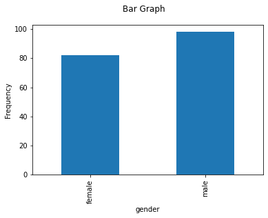

```python
x_df.groupby(['gender']).size().plot(kind='bar')

import matplotlib.pyplot as plt

plt.suptitle("Bar Graph")
plt.ylabel("Frequency")
```

Example: The dataset below (URL) contains students test1_score, test2_score,test3_score, gender, level, section etc.

Write a program to display a frequency pie chart for section.

https://raw.githubusercontent.com/simeonaman/demo/master/my_csv_file.csv

### Pie Chart

```python
import pandas as pd

url='https://raw.githubusercontent.com/simeonaman/demo/master/my_csv_file.csv'

x_df = pd.read_csv(url)
```

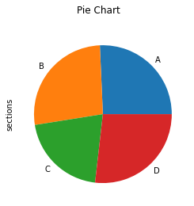

```python
x_df.groupby(['section']).size().plot(kind='pie')

import matplotlib.pyplot as plt

plt.suptitle("Pie Chart")
plt.ylabel("sections")
```

Example: The dataset below (URL) contains students test1_score, test2_score,test3_score, gender, level, section etc.

Write a program to display a box plot for test1_socre.

https://raw.githubusercontent.com/simeonaman/demo/master/my_csv_file.csv

### Box Plots

```python
import pandas as pd

url='https://raw.githubusercontent.com/simeonaman/demo/master/my_csv_file.csv'

x_df = pd.read_csv(url)
```

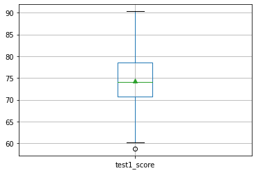

```python
x_df.boxplot(column=['test1_score'], showmeans = True)
```

Example: The dataset below (URL) contains students test1_score, test2_score,test3_score, gender, level, section etc.

Write a program to display box plot for test1_score grouped by level.

https://raw.githubusercontent.com/simeonaman/demo/master/my_csv_file.csv

```python
import pandas as pd

url='https://raw.githubusercontent.com/simeonaman/demo/master/my_csv_file.csv'

x_df = pd.read_csv(url)
```

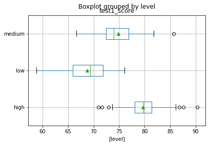

```python
x_df.boxplot(column=['test1_score'], by = ['level'], showmeans = True, vert = False)
```

Example: The dataset below (URL) contains students test1_score, test2_score,test3_score, gender, level, section etc.

Write a program to display box plot for test1_score grouped by gender.

https://raw.githubusercontent.com/simeonaman/demo/master/my_csv_file.csv

```python
import pandas as pd

url='https://raw.githubusercontent.com/simeonaman/demo/master/my_csv_file.csv'

x_df = pd.read_csv(url)
```

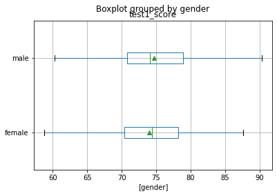

```python
x_df.boxplot(column=['test1_score'], by = ['gender'], showmeans = True, vert = False,)
```

Alternative solution to the above example using the `seaborn` visualization library

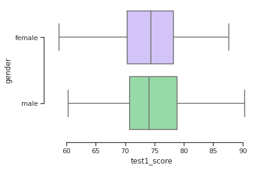

```python
import pandas as pd
import seaborn as sns
sns.set_theme(style="ticks", palette="pastel")

# Load the example tips dataset
url='https://raw.githubusercontent.com/simeonaman/demo/master/my_csv_file.csv'

x_df = pd.read_csv(url)

sns.boxplot(x="test1_score", y="gender", hue_order="smoker", palette=["m", "g"], data=x_df)
sns.despine(offset=10, trim=True)
```

Example: The dataset below (URL) contains students test1_score, test2_score,test3_score, gender, level, section etc.

https://raw.githubusercontent.com/simeonaman/demo/master/my_csv_file.csv

### Histograms

```python
import pandas as pd

url='https://raw.githubusercontent.com/simeonaman/demo/master/my_csv_file.csv'

x_df = pd.read_csv(url)
```

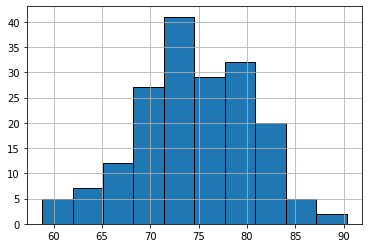

```python
x_df.test1_score.hist(bins=10, ec='k')
```

### Scatter plots

1. Write a program to read the dataset and display the basic information.
2. Write a program to display a scatter plot of `sqft_living` and `price`.
3. Write a program to display a scatter plot of `bathrooms` and `bedrooms`

https://raw.githubusercontent.com/Shreyas3108/house-price-prediction/master/kc_house_data.csv

```python
import pandas as pd

url = 'https://raw.githubusercontent.com/Shreyas3108/house-price-prediction/master/kc_house_data.csv'

x_df = pd.read_csv(url)

x_df.info()
```

```
<class 'pandas.core.frame.DataFrame'>
RangeIndex: 21613 entries, 0 to 21612
Data columns (total 21 columns):
 #   Column         Non-Null Count  Dtype
---  ------         --------------  -----
 0   id             21613 non-null  int64
 1   date           21613 non-null  object
 2   price          21613 non-null  float64
 3   bedrooms       21613 non-null  int64
 4   bathrooms      21613 non-null  float64
 5   sqft_living    21613 non-null  int64
 6   sqft_lot       21613 non-null  int64
 7   floors         21613 non-null  float64
 8   waterfront     21613 non-null  int64
 9   view           21613 non-null  int64
 10  condition      21613 non-null  int64
 11  grade          21613 non-null  int64
 12  sqft_above     21613 non-null  int64
 13  sqft_basement  21613 non-null  int64
 14  yr_built       21613 non-null  int64
 15  yr_renovated   21613 non-null  int64
 16  zipcode        21613 non-null  int64
 17  lat            21613 non-null  float64
 18  long           21613 non-null  float64
 19  sqft_living15  21613 non-null  int64
 20  sqft_lot15     21613 non-null  int64
dtypes: float64(5), int64(15), object(1)
memory usage: 3.5+ MB
```

Write a program to display a scatter plot of `sqft_living` and `price`.

https://raw.githubusercontent.com/Shreyas3108/house-price-prediction/master/kc_house_data.csv

```python
import pandas as pd

url = 'https://raw.githubusercontent.com/Shreyas3108/house-price-prediction/master/kc_house_data.csv'

x_df = pd.read_csv(url)
```

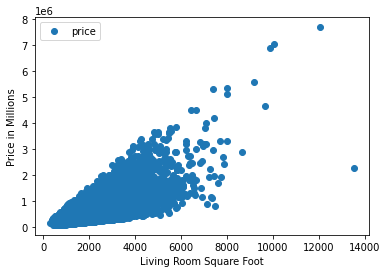

```python
x_df.plot('sqft_living','price',style='o', xlabel='Living Room Square Foot', ylabel='Price in Millions')
```

Write a program to display a scatter plot of `bathrooms` and `bedrooms`

https://raw.githubusercontent.com/Shreyas3108/house-price-prediction/master/kc_house_data.csv

```python
import pandas as pd

url = 'https://raw.githubusercontent.com/Shreyas3108/house-price-prediction/master/kc_house_data.csv'

x_df = pd.read_csv(url)
```

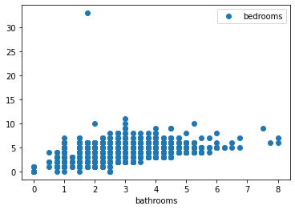

```python
x_df.plot('bathrooms','bedrooms',style='o')
```

## 14.5 Regression

### Multiple Linear Regression

[Watch demo video](https://youtu.be/vvpsbHbhZiY)

The **General Linear Model** $y=\beta_0+\beta_1x_1+\beta_2x_2+...+\beta_kx_k +\epsilon$ for multiple regression analysis where $y$ is the response variable we want to predict, $\beta_0,\beta_1,...,\beta_k$ are unknown constants, $x_1,x_2,...,x_k$ are independent predictor variables that are measured without error, and $\epsilon$ is the random error.

$\hat{y}=b_0+b_1x_1+b_2x_2+...+b_kx_k$ can be determined using the method of Least Squares as follows.

```
import statsmodels.formula.api as smf
model = smf.ols(formula='y ~ x1 + x2 +...+ xk', data=x_df)
results = model.fit()

print(results.summary())
```

Write a program to display basic information and the first five rows. x_df.info() and x_df.head().

https://raw.githubusercontent.com/Shreyas3108/house-price-prediction/master/kc_house_data.csv

```python
import pandas as pd

url = 'https://raw.githubusercontent.com/Shreyas3108/house-price-prediction/master/kc_house_data.csv'

x_df = pd.read_csv(url)
```

Interpretation: The above code uses pandas to read and save the dataset as pandas dataframe.

```python
x_df.info()
```

```
<class 'pandas.core.frame.DataFrame'>
RangeIndex: 21613 entries, 0 to 21612
Data columns (total 21 columns):
 #   Column         Non-Null Count  Dtype
---  ------         --------------  -----
 0   id             21613 non-null  int64
 1   date           21613 non-null  object
 2   price          21613 non-null  float64
 3   bedrooms       21613 non-null  int64
 4   bathrooms      21613 non-null  float64
 5   sqft_living    21613 non-null  int64
 6   sqft_lot       21613 non-null  int64
 7   floors         21613 non-null  float64
 8   waterfront     21613 non-null  int64
 9   view           21613 non-null  int64
 10  condition      21613 non-null  int64
 11  grade          21613 non-null  int64
 12  sqft_above     21613 non-null  int64
 13  sqft_basement  21613 non-null  int64
 14  yr_built       21613 non-null  int64
 15  yr_renovated   21613 non-null  int64
 16  zipcode        21613 non-null  int64
 17  lat            21613 non-null  float64
 18  long           21613 non-null  float64
 19  sqft_living15  21613 non-null  int64
 20  sqft_lot15     21613 non-null  int64
dtypes: float64(5), int64(15), object(1)
memory usage: 3.5+ MB
```

```python
x_df.head()
```

|  | id | date | price | bedrooms | bathrooms | sqft_living | sqft_lot | floors | waterfront | view | condition | grade | sqft_above | sqft_basement | yr_built | yr_renovated | zipcode | lat | long | sqft_living15 | sqft_lot15 |
| --- | --- | --- | --- | --- | --- | --- | --- | --- | --- | --- | --- | --- | --- | --- | --- | --- | --- | --- | --- | --- | --- |
| 0 | 7129300520 | 20141013T000000 | 221900.0 | 3 | 1.00 | 1180 | 5650 | 1.0 | 0 | 0 | 3 | 7 | 1180 | 0 | 1955 | 0 | 98178 | 47.5112 | -122.257 | 1340 | 5650 |
| 1 | 6414100192 | 20141209T000000 | 538000.0 | 3 | 2.25 | 2570 | 7242 | 2.0 | 0 | 0 | 3 | 7 | 2170 | 400 | 1951 | 1991 | 98125 | 47.7210 | -122.319 | 1690 | 7639 |
| 2 | 5631500400 | 20150225T000000 | 180000.0 | 2 | 1.00 | 770 | 10000 | 1.0 | 0 | 0 | 3 | 6 | 770 | 0 | 1933 | 0 | 98028 | 47.7379 | -122.233 | 2720 | 8062 |
| 3 | 2487200875 | 20141209T000000 | 604000.0 | 4 | 3.00 | 1960 | 5000 | 1.0 | 0 | 0 | 5 | 7 | 1050 | 910 | 1965 | 0 | 98136 | 47.5208 | -122.393 | 1360 | 5000 |
| 4 | 1954400510 | 20150218T000000 | 510000.0 | 3 | 2.00 | 1680 | 8080 | 1.0 | 0 | 0 | 3 | 8 | 1680 | 0 | 1987 | 0 | 98074 | 47.6168 | -122.045 | 1800 | 7503 |

1. Write a program to find the least-squares prediction equation, $y=\beta_0+\beta_1x_1+\beta_2x_2+\beta_3x_3 +\epsilon$ for these data where, $y$ is `price`, $x_1$ is `bedrooms`, $x_2$ `bathrooms` and $x_3$ is number of `floors`.
2. Use the overall F test to determine whether the model contributes significant information to the prediction of $y$ with 1% level of significance.
3. What is the value of R-squared. That is, the coefficient of determination.
4. Does the number of `floors`, $x_3$, contribute significant information for the prediction of the `price`, $y$, given that $x_1$ and $x_2$ are already in the model? (use $\alpha = 0.05$)

https://raw.githubusercontent.com/Shreyas3108/house-price-prediction/master/kc_house_data.csv

```python
import statsmodels.formula.api as smf
model = smf.ols(formula='price ~ bedrooms+bathrooms+floors', data=x_df)
results = model.fit()

print(results.summary())
```

```
                            OLS Regression Results
==============================================================================
Dep. Variable:                  price   R-squared:                       0.278
Model:                            OLS   Adj. R-squared:                  0.278
Method:                 Least Squares   F-statistic:                     2769.
Date:                Tue, 07 Sep 2021   Prob (F-statistic):               0.00
Time:                        21:32:40   Log-Likelihood:            -3.0409e+05
No. Observations:               21613   AIC:                         6.082e+05
Df Residuals:                   21609   BIC:                         6.082e+05
Df Model:                           3
Covariance Type:            nonrobust
==============================================================================
                 coef    std err          t      P>|t|      [0.025      0.975]
------------------------------------------------------------------------------
Intercept   -2.91e+04   9209.213     -3.160      0.002   -4.72e+04   -1.11e+04
bedrooms    2.002e+04   2680.838      7.469      0.000    1.48e+04    2.53e+04
bathrooms   2.385e+05   3681.888     64.766      0.000    2.31e+05    2.46e+05
floors     -1737.4719   4569.452     -0.380      0.704   -1.07e+04    7218.991
==============================================================================
Omnibus:                    17359.610   Durbin-Watson:                   1.961
Prob(Omnibus):                  0.000   Jarque-Bera (JB):           905901.534
Skew:                           3.476   Prob(JB):                         0.00
Kurtosis:                      33.946   Cond. No.                         20.4
==============================================================================

Warnings:
[1] Standard Errors assume that the covariance matrix of the errors is correctly specified.
```

Interpretation:

1. See `x_df.info()` and `x_df.head()` above
2. $\hat{y}=b_0+b_1x_1+b_2x_2+b_3x_3$ where $b_0=-2.91e+04$, $b_1=2.002e+04, b_2=2.385e+05, b_3=-1737.4719$
3. The F-statistic is 2769 with p-value of Prob (F-statistic) 0.00. Thus, the model has a significant contiribution to the prediction of price.
4. The coefficient of determination (R-squared:) is 0.278.
5. The p-value (P>|t|) for the floors is 0.704 which is not less than $\alpha = 0.05$. It is not significant.

### Logistic Regression

Logistic regression is the type of regression analysis used to find the probability of a certain event occurring. Best suited for cases where we have a categorical dichotomous dependent variable.

$p = \frac{1}{1+e^{\beta_0+\beta_1x_1+...+\beta_kx_k}}$ where $p$ is probability that $y=1$ and $y$ is the response variable with values 1s and 0s.

Example: The data set below (URL) contains the occurrence of choronary heart disease (`chd`), tobacco, obesity, age, alcohol, etc. For chd, 0 means patient has no chd and 1 means patient has chd.

1. Write a program to read the data set and display the first five rows.
2. Write a program to fit a logistic regression model where the dependent variable is `chd` (coronary heart disease) and the predictor variables are `tobacco`, `obesity` and `age`.
3. Use the LLR p-value test to determine whether the model contributes significant information to the prediction of $y$, `chd`, with 1% level of significance.

https://raw.githubusercontent.com/simeonaman/demo/master/heart.csv this dataset came from https://web.stanford.edu/~hastie/ElemStatLearn//datasets/SAheart.data

```python
import pandas as pd
x_df = pd.read_csv('https://raw.githubusercontent.com/simeonaman/demo/master/heart.csv')
x_df.head()
```

|  | row.names | sbp | tobacco | ldl | adiposity | famhist | typea | obesity | alcohol | age | chd |
| --- | --- | --- | --- | --- | --- | --- | --- | --- | --- | --- | --- |
| 0 | 1 | 160 | 12.00 | 5.73 | 23.11 | Present | 49 | 25.30 | 97.20 | 52 | 1 |
| 1 | 2 | 144 | 0.01 | 4.41 | 28.61 | Absent | 55 | 28.87 | 2.06 | 63 | 1 |
| 2 | 3 | 118 | 0.08 | 3.48 | 32.28 | Present | 52 | 29.14 | 3.81 | 46 | 0 |
| 3 | 4 | 170 | 7.50 | 6.41 | 38.03 | Present | 51 | 31.99 | 24.26 | 58 | 1 |
| 4 | 5 | 134 | 13.60 | 3.50 | 27.78 | Present | 60 | 25.99 | 57.34 | 49 | 1 |

```python
x_df.info()
```

```
<class 'pandas.core.frame.DataFrame'>
RangeIndex: 462 entries, 0 to 461
Data columns (total 11 columns):
 #   Column     Non-Null Count  Dtype
---  ------     --------------  -----
 0   row.names  462 non-null    int64
 1   sbp        462 non-null    int64
 2   tobacco    462 non-null    float64
 3   ldl        462 non-null    float64
 4   adiposity  462 non-null    float64
 5   famhist    462 non-null    object
 6   typea      462 non-null    int64
 7   obesity    462 non-null    float64
 8   alcohol    462 non-null    float64
 9   age        462 non-null    int64
 10  chd        462 non-null    int64
dtypes: float64(5), int64(5), object(1)
memory usage: 39.8+ KB
```

Example: The data set below (URL) contains the occurrence of coronary heart disease (`chd`), tobacco, obesity, age, alcohol, etc. For chd, 0 means patient has no chd and 1 means patient has chd.

1. Write a program to fit a logistic regression model where the dependent variable is `chd` (coronary heart disease) and the predictor variables are `tobacco`, `obesity` and `age`.
2. Use the LLR p-value test to determine whether the model contributes significant information to the prediction of $y$, `chd`, with 1% level of significance.

https://raw.githubusercontent.com/simeonaman/demo/master/heart.csv this dataset came from https://web.stanford.edu/~hastie/ElemStatLearn//datasets/SAheart.data

```python
import pandas as pd
x_df = pd.read_csv('https://raw.githubusercontent.com/simeonaman/demo/master/heart.csv')
```

```python
import statsmodels.formula.api as smf
model = smf.logit(formula='chd ~ tobacco + obesity + age', data=x_df)
results = model.fit()

print(results.summary())
```

```
Optimization terminated successfully.
         Current function value: 0.557771
         Iterations 6
                           Logit Regression Results
==============================================================================
Dep. Variable:                    chd   No. Observations:                  462
Model:                          Logit   Df Residuals:                      458
Method:                           MLE   Df Model:                            3
Date:                Tue, 07 Sep 2021   Pseudo R-squ.:                  0.1354
Time:                        21:32:40   Log-Likelihood:                -257.69
converged:                       True   LL-Null:                       -298.05
Covariance Type:            nonrobust   LLR p-value:                 2.142e-17
==============================================================================
                 coef    std err          z      P>|z|      [0.025      0.975]
------------------------------------------------------------------------------
Intercept     -3.4213      0.753     -4.541      0.000      -4.898      -1.945
tobacco        0.0788      0.026      3.061      0.002       0.028       0.129
obesity        0.0019      0.026      0.074      0.941      -0.050       0.054
age            0.0538      0.009      5.808      0.000       0.036       0.072
==============================================================================
```

## 14.6 ANOVA (Analysis of Variance)

[Watch demo video](https://youtu.be/pBQlzsoLnQs)

### One-Way ANOVA

ANOVA (analysis of variance) can be used to test whether the means of more than two groups are statistically different from each other.

Example: The data set below (URL) contains the students test1_score, gender, level, section etc.

1. Write a program to read the data set and display the first and last five rows.
2. Write a program to find `test1_score` means, std and size for each level

https://raw.githubusercontent.com/simeonaman/demo/master/my_csv_file.csv

```python
import pandas as pd

url='https://raw.githubusercontent.com/simeonaman/demo/master/my_csv_file.csv'

x_df = pd.read_csv(url)

x_df  # print the first and last five rows
```

|  | id | gender | section | time | level | test1_score | test2_score | test3_score |
| --- | --- | --- | --- | --- | --- | --- | --- | --- |
| 0 | 1 | female | C | 17.3 | low | 65.4 | 84.3 | 51.9 |
| 1 | 2 | female | D | 5.1 | low | 72.4 | 86.1 | 52.0 |
| 2 | 3 | female | A | 2.4 | low | 73.8 | 84.2 | 53.1 |
| 3 | 4 | female | A | 8.8 | low | 70.2 | 87.9 | 52.0 |
| 4 | 5 | male | B | 15.0 | low | 60.3 | 81.4 | 55.5 |
| ... | ... | ... | ... | ... | ... | ... | ... | ... |
| 175 | 176 | male | B | 13.2 | high | 78.8 | 89.3 | 52.5 |
| 176 | 177 | female | B | 12.6 | high | 76.5 | 83.4 | 50.0 |
| 177 | 178 | male | D | 8.4 | high | 78.1 | 86.3 | 51.0 |
| 178 | 179 | male | C | 9.5 | high | 76.6 | 86.6 | 52.4 |
| 179 | 180 | male | C | 16.2 | high | 83.1 | 89.4 | 54.1 |

180 rows Ã— 8 columns

```python
x_df.groupby(['level']).agg({'test1_score': ['mean', 'std','size']})
```

| level | test1_score mean | test1_score std | test1_score size |
| --- | --- | --- | --- |
| high | 79.613333 | 3.617306 | 60 |
| low | 68.775000 | 4.350282 | 60 |
| medium | 74.841667 | 3.638881 | 60 |

Example: The data set below (URL) contains the students test1_score, gender, level, section etc.

- Write a program to perform ANOVA to test if there is sufficient evidence to indicate a difference in the averages of `test1_scores` among the three `levels` (low, medium, high). Use 10% level of significance.

https://raw.githubusercontent.com/simeonaman/demo/master/my_csv_file.csv

```python
import statsmodels.api as sm
from statsmodels.formula.api import ols
model = ols('test1_score ~ C(level)',data = x_df).fit()
table = sm.stats.anova_lm(model,type=2) # type 2 for equal or non-equal sample sizes
print(table)
```

```
             df       sum_sq      mean_sq           F        PR(>F)
C(level)    2.0  3540.854333  1770.427167  117.372972  3.555808e-33
Residual  177.0  2669.827667    15.083772         NaN           NaN
```

Interpretation: Since the p-value 3.555808e-33 < $\alpha$ = 0.10, reject the null hypothesis that the averages for all three levels are equal. That is, there is a significant difference between the averages of test1_score of the three levels. The sum of squares residual is 2669.827667. The sum of squares treatment (level) is 3540.854333.

## Tukey's Paired Mean Test

Example: For the above example, use Tukey's method for paired comparisons to determine which pairs of the three level means are different.

```python
import statsmodels.stats.multicomp as mc
comp = mc.MultiComparison(x_df['test1_score'], x_df['level'])
post_hoc_res = comp.tukeyhsd(alpha=0.05)
print(post_hoc_res.summary())
```

```
Multiple Comparison of Means - Tukey HSD, FWER=0.05
====================================================
group1 group2 meandiff p-adj  lower    upper  reject
----------------------------------------------------
  high    low -10.8383 0.001 -12.5144 -9.1622   True
  high medium  -4.7717 0.001  -6.4478 -3.0956   True
   low medium   6.0667 0.001   4.3906  7.7428   True
----------------------------------------------------
```

Interpretation: All pairwise mean comparisons are significant. That is, the mean score1_difference between high and low, high and medium, and low and medium are significantly different.

### Two-way ANOVA (Block Design)

Example: The data set below (URL) contains students test1_score, gender, level, section etc.

1. Write a program to read the dataset and display the first rows.
2. Write a program to find `test1_score` means grouped by `level` and `gender`.
3. Write a program to perform ANOVA block design to test if there is sufficient evidence to indicate a difference in the averages of test1_scores among the three levels (low, medium, high) using gender as blocks. Use 10% level of significance.

https://raw.githubusercontent.com/simeonaman/demo/master/my_csv_file.csv

```python
import pandas as pd

url='https://raw.githubusercontent.com/simeonaman/demo/master/my_csv_file.csv'

x_df = pd.read_csv(url)

x_df.head()  # print the first five rows
```

|  | id | gender | section | time | level | test1_score | test2_score | test3_score |
| --- | --- | --- | --- | --- | --- | --- | --- | --- |
| 0 | 1 | female | C | 17.3 | low | 65.4 | 84.3 | 51.9 |
| 1 | 2 | female | D | 5.1 | low | 72.4 | 86.1 | 52.0 |
| 2 | 3 | female | A | 2.4 | low | 73.8 | 84.2 | 53.1 |
| 3 | 4 | female | A | 8.8 | low | 70.2 | 87.9 | 52.0 |
| 4 | 5 | male | B | 15.0 | low | 60.3 | 81.4 | 55.5 |

```python
x_df.groupby(['level','gender']).agg({'test1_score': ['mean', 'std','size']})
```

| level | gender | test1_score mean | test1_score std | test1_score size |
| --- | --- | --- | --- | --- |
| high | female | 79.684000 | 3.637728 | 25 |
|  | male | 79.562857 | 3.654979 | 35 |
| low | female | 68.469697 | 4.876377 | 33 |
|  | male | 69.148148 | 3.662741 | 27 |
| medium | female | 75.729167 | 2.804884 | 24 |
|  | male | 74.250000 | 4.031271 | 36 |

```python
import statsmodels.api as sm
from statsmodels.formula.api import ols
model = ols('test1_score ~ C(level) + C(gender)',data = x_df).fit()
table = sm.stats.anova_lm(model,type=2) # type 2 for non-equal sample sizes
print(table)
```

```
              df       sum_sq      mean_sq           F        PR(>F)
C(level)     2.0  3540.854333  1770.427167  116.878417  5.044391e-33
C(gender)    1.0     3.850572     3.850572    0.254203  6.147613e-01
Residual   176.0  2665.977095    15.147597         NaN           NaN
```

Interpretation: There is significant difference of the test1_score means between the three levles afte blocking by gender. No significant difference in the average test1_scores between the two genders.

### Two-Factor ANOVA (Interactions)

Example: The dataset below (URL) contains students `test1_score`, `gender`, `level`, `section` etc.

1. Write a program to read the dataset and display the first 5 rows.
2. Write a program to display the means grouped by `level` and `interaction`
3. Write a program to perform a two-factor ANOVA with `level` and `section`. Do the data provide sufficient evidence to indicate an interaction between `level` and `section`? Use 10% level of significance.

https://raw.githubusercontent.com/simeonaman/demo/master/my_csv_file.csv

```python
import pandas as pd

url='https://raw.githubusercontent.com/simeonaman/demo/master/my_csv_file.csv'

x_df = pd.read_csv(url)
```

```python
x_df.groupby(['level','section']).agg({'test1_score': ['mean', 'std','size']})
```

| level | section | test1_score mean | test1_score std | test1_score size |
| --- | --- | --- | --- | --- |
| high | A | 79.714286 | 4.442601 | 14 |
|  | B | 79.292308 | 4.325402 | 13 |
|  | C | 79.426667 | 3.944339 | 15 |
|  | D | 79.835294 | 2.047542 | 17 |
| low | A | 67.346667 | 4.704840 | 15 |
|  | B | 67.931250 | 4.311646 | 16 |
|  | C | 67.993750 | 3.560238 | 16 |
|  | D | 72.423077 | 3.067614 | 13 |
| medium | A | 74.811765 | 2.812002 | 17 |
|  | B | 74.721053 | 4.207081 | 19 |
|  | C | 73.016667 | 2.343857 | 6 |
|  | D | 75.605556 | 4.043073 | 18 |

```python
import statsmodels.api as sm
from statsmodels.formula.api import ols
model = ols('test1_score ~ C(level)*C(section)',data = x_df).fit()
table = sm.stats.anova_lm(model,type=2) # type 2 for non-equal sample sizes
print(table)
```

```
                        df       sum_sq      mean_sq           F        PR(>F)
C(level)               2.0  3494.967554  1747.483777  121.179409  3.062871e-33
C(section)             3.0   125.235378    41.745126    2.894819  3.687668e-02
C(level):C(section)    6.0   133.100312    22.183385    1.538309  1.685520e-01
Residual             167.0  2408.245695    14.420633         NaN           NaN
```

Interpretation: There is no significant interaction effect between `level` and `section` of the average `test1_score`, because the p-value 1.685520e-01 is not less than the level of significance .10.

The End

# **Appendix 1: Python Installing Steps**

**Python Computer Installation**

If you prefer not to use Google Colab Notebook, you can install free Python in your computer and use the **Anaconda Jupyter Notebook**. Go to [this website](https://www.anaconda.com/products/individual#Downloads) and select Windows, MacOS or Linux, depending on your computer. When the installation is completed, open **jupyter Notebook(anaconda3)** from the **Anaconda** folder on your computer. You can also watch YouTube videos on how to install Anaconda for [Windows 10](https://youtu.be/g6ln1dAt-RI) or [MacOS](https://youtu.be/V6ZAv7hBH6Y).

Open **Jupyter Notebook** from your Windows computer Start menu under **Anaconda** and click **new**. You can add new code-cell or text-cell by clicking + and code (see pictures below). You can run a code-cell by clicking **run**.

[figure not shown]

[figure not shown]

# **Appendix 2: Random Integer Generator**

[Watch demo video](https://watch.screencastify.com/v/KIDjEiCx10j6cnhERP12)

"A random number generator, generates a sequence of numbers or symbols that cannot be reasonably predicted better than by a random chance." Wikipedia

To randomly generate $n$ integers between $a$ and $b$, inclusive, use the following function from the numpy library. Here $n,a$ and $b$ are integers.

```
import numpy as np
np.random.randint(a, b+1, size=n)
```

Example: Write a program to randomly select one integer between 1 and 10.

1. Click `+ Code`
2. Type `import numpy as np`
3. Type `np.random.randint(1,10+1,size=1)`
4. Click `play` button

```python
import numpy as np
np.random.randint(1,10+1,size=1)
```

```
array([5])
```

Interpretation: The number 5 is randomly selected from all integers between 1 and 10. If you run this program again, it will, most likely, generate a different result.

Example: Write a program to randomly select 3 integers between 1 and 32.

```python
import numpy as np
np.random.randint(1,32+1,size=3)
```

```
array([22, 13,  5])
```

Interpretation: 22, 13, and 5 are randomly selected from all integers between 1 and 32.

Example: Write a program to randomly select 10 integers between 1 and 100. Save the result in a variable named x and print x.

```python
import numpy as np
x = np.random.randint(1,100+1,size=10)
x
```

```
array([59, 65, 14, 79, 42, 44,  4, 30, 38, 40])
```

Interpretation: The 10 numbers randomly selected from all integers between 1 and 100 are 59, 65, 14, 79, 42, 44, 4, 30, 38, 40.

To get the same result in every run, add `np.random.seed(n)` where n is any non-negative integer.

Example: Write a program to randomly select 3 integers between 1 and 32. Use the seed number 123.

```python
import numpy as np
np.random.seed(123)  # fix seed to get the same result
np.random.randint(1,32+1,size=3)
```

```
array([31, 14, 31])
```

Interpretation: The 3 numbers randomly selected with the given seed are 31, 14 and 31.

```python
import numpy as np
np.random.seed(123)  # fix seed to get the same result
np.random.randint(1,32+1,size=3)
```

```
array([31, 14, 31])
```

Interpretation: By adding `np.random.seed(123)`, we are able to generate the same set of numbers all the time.

# **Appendix 3: Counting, Permutations and Combinations**

In probability experiment, counting the number of outcomes in a trial or the total number of all possible outcomes is essential.

## Factorial, Permutation, Combination

[Watch demo video](https://watch.screencastify.com/v/DBZauBKSZpeyS1O5WFw2)

The number of ways we can arrange $n$ distinct objects is given by:

$n!=n\times (n-1)\times (n-2) ...2 \times 1$

The number of ways we can arrange 5 distinct objects is:

$5!=5\times 4\times 3\times 2 \times 1$

Syntax for factorial:

```
import numpy as np
np.math.factorial(n)
```

The number of ways we can arrange $n$ distinct objects, taking them $r$ at a time is given by:

$nPr = \frac{n!}{(n-r)!}$

```
import numpy as np
np.math.factorial(n)/np.math.factorial(n-r)
```

The number of distinct combinations of $n$ distinct objects that can be formed by taking $r$ at a time is given by:

$nCr = \frac{n!}{r!(n-r)!}$

```
import numpy as np
np.math.factorial(n)/(np.math.factorial(r)*np.math.factorial(n-r))
```

Example: For $n=6$ and $r=3$, compute the following:

1. $n!$
2. $nPr$
3. $nCr$

```python
import numpy as np
np.math.factorial(6)
```

```
720
```

Interpretation: 6!=720. There 720 different arrangement of 6 distinct objects.

```python
import numpy as np
np.math.factorial(6)/np.math.factorial(6-3)
```

```
120.0
```

Interpretation: there are 120 permutations of 6 objects taking 3 at a time.

```python
import numpy as np
np.math.factorial(6)/(np.math.factorial(3)*np.math.factorial(6-3))
```

```
20.0
```

Interpretation: There are 20 combinations (without regard to order) of 6 objects taking 3 at a time.

# **Code References**

## Arithmetic Operators

| Name | Operator | Example | Result |
| --- | --- | --- | --- |
| Addition | `+` | `5+6` | `11` |
| Subtraction | `-` | 5-6 | `-1` |
| Multiplication | `*` | `5*6` | `30` |
| Division | `/` | `5/6` | `0.83333` |
| Exponentiation | `**` | `5**2` | $5^2$ =`25` |

## Descriptive Stats

```
import numpy as np
import pandas as pd

x=[x1,x2,x3,...]

x_df=pd.DataFrame({'column_name':x})
```

| procedure | numpy | pandas |
| --- | --- | --- |
| frequency counts | `np.unique(x,return_counts=True)` | `x_df.value_counts()` |
| size | `np.size(x)` | `x_df.count()` |
| min | `np.amin(x)` | `x_df.min()` |
| max | `np.amax(x)` | `x_df.max()` |
| mean | `np.mean(x)` | `x_df.mean()` |
| mode | NA | `x_df.mode()` |
| median | `np.median(x)` | `x_df.median()` |
| sample variance | `np.var(x,ddf=1)` | `x_df.var()` |
| pop variance | `np.var(x)` | `x_df.var(ddof=0)` |
| sample std | `np.std(x,ddof=1)` | `x_df.std()` |
| pop std | `np.std(x)` | `x_df.std(ddof=0)` |
| weighted mean | `np.average(x,weights=freq)` | NA |
| weighted sample std | `(np.cov(x,fweights=freq,dd0f=1))**(1/2)` | NA |
| weighted pop std | `(np.cov(x,fweights=freq))**(1/2)` | NA |
| percentiles | `np.quantile(x,p)` | `x_df.quantile(p)` |
| summary stats | NA | `x_df.describe()` |
| factorial, n! | `np.math.factorial(n)` | NA |
| n random integers from a to b | `np.random.randint(a,b+1,size=n)` | NA |
| weighted mean | `np.average(x,weights=y)` | NA |
| Weighted std | `(np.cov(x,aweights=y,ddof=0)**(1/2)` | NA |
| correlation coef. | `np.corrcoef(x,y)` | `x_df.corr()` |

NA = Not Available

Summary statistics by grouping with categorical columns:

```
x_df.groupby(['level','gender']).agg({'test1_score':
                  ['mean','std','size']})
```

## Graphs

```
import pandas as pd
import mathplotlib.pyplot as plt

x = [x1, x2, x3, ...]
x_df = pd.DataFrame({'column_name',x})

CHOOSE A CODE FROM BELOW (Bar, Pie, Histogram etc)

plt.suptitle("Plot Title")
plt.xlabel("x-axis label")
plt.ylabel("y-axis label")
```

1. Bar graph (raw data) `x_df.groupby(['column_name']).size().plot(kind='bar')`
2. Pie Chart (raw data)

   ```
   x_df.groupby(['column_name']).size().plot(kind='pie',
                         autopct='%1.1f%%')
   ```

3. Bar graph (frequency table) `x_df.plot.bar(x='column_name',y='frequency')`
4. Pie chart (frequency table)

```
x_df.set_index('column_name',inplace=True)
x_df.plot.pie(y='frequency')
```

5. Side by Side Bar (frequency table)

```
x_df.set_index('column_name',inplace=True)
x_df.plot.bar()
```

6. Histogram

```
freq,bins,patches = plt.hist(x,bins=5,ec='k',range=[min(x),max(x)+1])
plt.xticks(bins)   # df['column_name']=x
```

7. Scater Plot (x, y list given) `plt.scatter(x,y)`

## Linear Regression

```
from scipy import stats
stats.linregress(x_list, y_list)
```

## Multiple Linear Regression

```
import statsmodels.formula.api as smf
model = smf.ols(formula='y ~ x1 + x2 +...+ xk', data=x_df)
results = model.fit()

print(results.summary())
```

## Probability Distributions

```
from scipy import stats
```

| procedure | scipy.stats |
| --- | --- |
| Binomial pdf $P(X=x)$ | `stats.binom.pmf(x,n,p)` |
| Binomial cdf $P(X\le x)$ | `stats.binom.cdf(x,n,p)` |
| Normal cdf $P(X\le x)$ | `stats.norm.cdf(x,mean,std)` |
| Inverse Normal or p-th Percentile | `stats.norm.ppf(p,mean,std)` |
| *t* distribution cdf $P(X\le x)$ | `stats.t.cdf(t,df,0,1)` |
| Inverse *t* or p-th Percentile | `stats.t.ppf(p,df,0,1)` |
| chi-square cdf $P(\chi^2 \le ch2)$ | `stats.chi2.cdf(ch2,k-1)` |
| Inverse chi-square or p-th Percentile | `stats.chi2.ppf(p,k-1)` |

## Margin of Error for Confidence Interval

```
from scipy import stats
```

Mean $\mu$ with $z$ distribution with confidence level `C`, (population) standard deviation `std` and sample size `n`:

```
E = (std/n**.5)*stats.norm.ppf(C+(1-C)/2,0,1)
```

Mean $\mu$ with $t$ distribution with confidence level `C`, sample standard deviation `std` and sample size `n`:

```
E = (std/n**.5)*stats.t.ppf(C+(1-C)/2,0,1)
```

Proportion $p$ with $z$ distribution with confidence level `C`, sample proportion `p` and sample size `n`:

```
E = (p(p*(1-p)/n)**.5)*stats.norm.ppf(C+(1-C)/2,0,1)
```

# **Resources**

- [Python.org](https://www.python.org/)
- [Matplotlib](https://matplotlib.org/stable/api/_as_gen/matplotlib.pyplot.boxplot.html)
- [Python eBook](https://greenteapress.com/thinkpython/html/index.html)
- [Introductory Statistics eBook](https://openstax.org/books/introductory-statistics/pages/1-introduction)
- [Python Tutorials](https://www.w3schools.com/python/default.asp)
- [Terminology](https://www.computerhope.com/jargon/program.htm#i)
- [Numpy](https://numpy.org/doc/stable/user/absolute_beginners.html)
- [Scipy Stats](https://docs.scipy.org/doc/scipy/reference/stats.html#) -[Pandas](https://pandas.pydata.org/docs/getting_started/intro_tutorials/index.html)